# Bioinformatics Project

Sergio Fernandez - Alessandro Mecchia - Paolo Nicolet

2026-01-08

# Imports and packages

```r
BiocManager::install("recount3")
n
BiocManager::install("org.Hs.eg.db")
n
install.packages("tidyverse")
install.packages("pheatmap")
install.packages("tidyverse")
```

```r
library(recount3)
library(tidyr)
library(dplyr)
library(ggplot2)
library(plotly)
library(stringr)
library(edgeR)
library(pheatmap)
library(gplots)
library(RColorBrewer)
library(org.Hs.eg.db)
library(AnnotationDbi)
```

```r
library(clusterProfiler)
library(org.Hs.eg.db)
library(enrichplot)
```

# 1. Project Introduction

# 2. Dataset Selection

```r
# List of available projects
projects <- available_projects()
projects
```

| project | organism | file_source | project_home | project_type | n_samples |
| --- | --- | --- | --- | --- | --- |
| SRP107565 | human | sra | data_sources/sra | data_sources | 216 |
| SRP149665 | human | sra | data_sources/sra | data_sources | 4 |
| SRP017465 | human | sra | data_sources/sra | data_sources | 23 |
| SRP119165 | human | sra | data_sources/sra | data_sources | 6 |
| SRP133965 | human | sra | data_sources/sra | data_sources | 12 |
| SRP096765 | human | sra | data_sources/sra | data_sources | 7 |
| SRP124965 | human | sra | data_sources/sra | data_sources | 12 |
| SRP189165 | human | sra | data_sources/sra | data_sources | 15 |
| SRP050365 | human | sra | data_sources/sra | data_sources | 10 |
| SRP123065 | human | sra | data_sources/sra | data_sources | 41 |

[output cut: 990 more lines]

```r
NA
```

```r
# Filter by GTEx (normal tissues)
gtex_projects <- subset(projects, file_source == "gtex")

# Explore metadata
gtex_projects
```

|  | project | organism | file_source | project_home | project_type | n_samples |
| --- | --- | --- | --- | --- | --- | --- |
| 8678 | ADIPOSE_TISSUE | human | gtex | data_sources/gtex | data_sources | 1293 |
| 8679 | MUSCLE | human | gtex | data_sources/gtex | data_sources | 881 |
| 8680 | BLOOD_VESSEL | human | gtex | data_sources/gtex | data_sources | 1398 |
| 8681 | HEART | human | gtex | data_sources/gtex | data_sources | 942 |
| 8682 | OVARY | human | gtex | data_sources/gtex | data_sources | 195 |
| 8683 | UTERUS | human | gtex | data_sources/gtex | data_sources | 159 |
| 8684 | VAGINA | human | gtex | data_sources/gtex | data_sources | 173 |
| 8685 | BREAST | human | gtex | data_sources/gtex | data_sources | 482 |
| 8686 | SKIN | human | gtex | data_sources/gtex | data_sources | 1940 |
| 8687 | SALIVARY_GLAND | human | gtex | data_sources/gtex | data_sources | 178 |

[output cut: 22 more lines]

```r
proj_info_pancreas <- subset(
    gtex_projects,
    project == "BRAIN" & project_type == "data_sources"
)

# Connet to GTEx project
rse_gene_BRAIN <- create_rse(proj_info_pancreas)
```

```
|--------------------------------------------------|
|==================================================|
```

```r
rse_gene_BRAIN
```

```
class: RangedSummarizedExperiment
dim: 63856 2931
metadata(8): time_created recount3_version ... annotation recount3_url
assays(1): raw_counts
rownames(63856): ENSG00000278704.1 ENSG00000277400.1 ... ENSG00000182484.15_PAR_Y ENSG00000227159.8_PAR_Y
rowData names(10): source type ... havana_gene tag
colnames(2931): GTEX-T6MN-0011-R1A-SM-32QOY.1 GTEX-WWYW-3126-SM-3NB39.1 ... GTEX-1O9I2-3026-SM-E76PX.1
  GTEX-1OJC4-2826-SM-E6CQX.1
colData names(198): rail_id external_id ... recount_seq_qc.errq BigWigURL
```

```r
colnames(colData(rse_gene_BRAIN))
```

```
  [1] "rail_id"
  [2] "external_id"
  [3] "study"
  [4] "gtex.run_acc"
  [5] "gtex.subjid"
  [6] "gtex.sex"
  [7] "gtex.age"
  [8] "gtex.dthhrdy"
  [9] "gtex.sampid"
 [10] "gtex.smatsscr"
 [11] "gtex.smcenter"
 [12] "gtex.smpthnts"
 [13] "gtex.smrin"
 [14] "gtex.smts"
 [15] "gtex.smtsd"
```

[output cut: 183 more lines]

```r
# Filter by TCGA (the cancer genome atlas)
tcga_projects <- subset(projects, file_source== "tcga")

# Explore metadata
tcga_projects
```

|  | project | organism | file_source | project_home | project_type | n_samples |
| --- | --- | --- | --- | --- | --- | --- |
| 8710 | ACC | human | tcga | data_sources/tcga | data_sources | 79 |
| 8711 | BLCA | human | tcga | data_sources/tcga | data_sources | 433 |
| 8712 | BRCA | human | tcga | data_sources/tcga | data_sources | 1256 |
| 8713 | CESC | human | tcga | data_sources/tcga | data_sources | 309 |
| 8714 | CHOL | human | tcga | data_sources/tcga | data_sources | 45 |
| 8715 | COAD | human | tcga | data_sources/tcga | data_sources | 546 |
| 8716 | DLBC | human | tcga | data_sources/tcga | data_sources | 48 |
| 8717 | ESCA | human | tcga | data_sources/tcga | data_sources | 198 |
| 8718 | GBM | human | tcga | data_sources/tcga | data_sources | 175 |
| 8719 | HNSC | human | tcga | data_sources/tcga | data_sources | 548 |

[output cut: 23 more lines]

```r
proj_info_gbm <- subset(
  tcga_projects,
  project == "GBM" & project_type == "data_sources"
)

rse_gene_tcga <- create_rse(proj_info_gbm, type = "gene")

metadata_tcga <- colData(rse_gene_tcga)
all_cols <- colnames(metadata_tcga)

diagnosis_cols <- grep("^tcga\\.gdc_cases\\.diagnoses", all_cols, value = TRUE)
print(diagnosis_cols)
```

```
 [1] "tcga.gdc_cases.diagnoses.classification_of_tumor"   "tcga.gdc_cases.diagnoses.primary_diagnosis"
 [3] "tcga.gdc_cases.diagnoses.submitter_id"              "tcga.gdc_cases.diagnoses.tumor_stage"
 [5] "tcga.gdc_cases.diagnoses.age_at_diagnosis"          "tcga.gdc_cases.diagnoses.vital_status"
 [7] "tcga.gdc_cases.diagnoses.morphology"                "tcga.gdc_cases.diagnoses.days_to_death"
 [9] "tcga.gdc_cases.diagnoses.days_to_last_follow_up"    "tcga.gdc_cases.diagnoses.diagnosis_id"
[11] "tcga.gdc_cases.diagnoses.tissue_or_organ_of_origin" "tcga.gdc_cases.diagnoses.days_to_birth"
[13] "tcga.gdc_cases.diagnoses.treatments.submitter_id"   "tcga.gdc_cases.diagnoses.treatments.treatment_id"
```

```r
demo_cols <- grep("^tcga\\.gdc_cases\\.demographic", all_cols, value = TRUE)
print(demo_cols)
```

```
[1] "tcga.gdc_cases.demographic.updated_datetime" "tcga.gdc_cases.demographic.gender"
[3] "tcga.gdc_cases.demographic.submitter_id"     "tcga.gdc_cases.demographic.year_of_birth"
[5] "tcga.gdc_cases.demographic.race"             "tcga.gdc_cases.demographic.demographic_id"
[7] "tcga.gdc_cases.demographic.ethnicity"        "tcga.gdc_cases.demographic.year_of_death"
```

```r
rse_gene_tcga
```

```
class: RangedSummarizedExperiment
dim: 63856 175
metadata(8): time_created recount3_version ... annotation recount3_url
assays(1): raw_counts
rownames(63856): ENSG00000278704.1 ENSG00000277400.1 ... ENSG00000182484.15_PAR_Y ENSG00000227159.8_PAR_Y
rowData names(10): source type ... havana_gene tag
colnames(175): 3b7f80e6-74a7-4da1-ac4b-c260b6be880a 97a8e2b1-059b-4527-8fb4-116f718ffd16 ...
  2dab6792-f9af-4565-bdd5-c9802f3132f4 c33edb64-c7b9-49a1-ae73-1d293f8522f6
colData names(937): rail_id external_id ... recount_seq_qc.errq BigWigURL
```

## 2.1. Dataset Reduction

```r
md_gtex <- as.data.frame(colData(rse_gene_BRAIN))
md_tcga <- as.data.frame(colData(rse_gene_tcga))
```

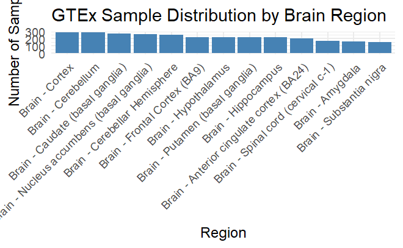

```r
gtex_counts <- as.data.frame(table(md_gtex$gtex.smtsd))
colnames(gtex_counts) <- c("Region", "Count")

ggplot(gtex_counts, aes(x = reorder(Region, -Count), y = Count)) +
  geom_bar(stat = "identity", fill = "steelblue") +
  theme_minimal() +
  theme(axis.text.x = element_text(angle = 45, hjust = 1)) +
  labs(title = "GTEx Sample Distribution by Brain Region",
       x = "Region",
       y = "Number of Samples")
```

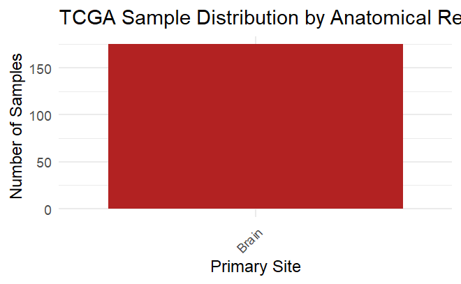

```r
tcga_site_counts <- as.data.frame(table(md_tcga$tcga.gdc_cases.project.primary_site))
colnames(tcga_site_counts) <- c("Region", "Count")

ggplot(tcga_site_counts, aes(x = reorder(Region, -Count), y = Count)) +
  geom_bar(stat = "identity", fill = "firebrick") +
  theme_minimal() +
  theme(axis.text.x = element_text(angle = 45, hjust = 1)) +
  labs(title = "TCGA Sample Distribution by Anatomical Region",
       x = "Primary Site",
       y = "Number of Samples")
```

```r
rse_gene_BRAIN <- rse_gene_BRAIN[, rse_gene_BRAIN$gtex.smtsd == "Brain - Cortex"]
```

# 3. Data Exploration

## 3.1. Age distribution

```r
age_gtex <- md_gtex$gtex.age
head(age_gtex)
```

```
[1] "50-59" "50-59" "50-59" "40-49" "50-59" "60-69"
```

```r
age_tcga <- md_tcga$tcga.gdc_cases.diagnoses.age_at_diagnosis
head(age_tcga)
```

```
[1] 26796 21384 19053 23343 20159 17880
```

```r
gtex_bins   <- c(20,30,40,50,60,70,80, Inf)
gtex_labels <- c("20-29","30-39","40-49","50-59","60-69","70-79","80+")

df_age_perc <- bind_rows(
  data.frame(
    age_bin = factor(md_gtex$gtex.age, levels = gtex_labels),
    dataset = "GTEx"
  ),
  data.frame(
    age = as.numeric(md_tcga$tcga.gdc_cases.diagnoses.age_at_diagnosis) / 365.25,
    dataset = "TCGA"
  ) %>%
    mutate(age_bin = cut(age, breaks = gtex_bins, labels = gtex_labels, right = FALSE))
) %>%
  filter(!is.na(age_bin)) %>%
  count(dataset, age_bin) %>%
  group_by(dataset) %>%
  mutate(percent = n / sum(n) * 100) %>%
  ungroup()
```

```r
p <- ggplot(
  df_age_perc,
  aes(x = age_bin, y = percent, fill = dataset)
) +
  geom_col(position = "dodge") +
  labs(
    x = "Age range (years)",
    y = "Percentage of samples",
    title = "Normalized age distribution: GTEx vs TCGA"
  ) +
theme_minimal() +
  theme(axis.text.x = element_text(angle = 45, hjust = 1))

ggplotly(p)
```

[interactive chart not shown]

```r
NA
```

## 3.2. Sex Distribution

```r
sex_gtex <- md_gtex$gtex.sex %>%
  recode(
    `1` = "Male",
    `2` = "Female"
  )

sex_tcga <- md_tcga$tcga.gdc_cases.demographic.gender
```

```r
df_sex <- bind_rows(
  data.frame(
    sex = sex_gtex,
    dataset = "GTEx"
  ),
  data.frame(
    sex = sex_tcga,
    dataset = "TCGA"
  )
) %>%
  filter(!is.na(sex)) %>%
  mutate(sex = str_to_title(sex)) %>%
  count(dataset, sex) %>%
  group_by(dataset) %>%
  mutate(percent = n / sum(n) * 100) %>%
  ungroup()
```

```r
p_sex <- ggplot(
  df_sex,
  aes(x = sex, y = percent, fill = dataset)
) +
  geom_col(position = "dodge") +
  labs(
    x = "Sex",
    y = "Percentage of samples",
    title = "Sex distribution: GTEx vs TCGA"
  ) +
  theme_minimal()

ggplotly(p_sex)
```

[interactive chart not shown]

```r
NA
```

## 3.3. RNA Quality

```r
df_qc_long <- bind_rows(
  md_gtex %>%
    transmute(
      dataset = "GTEx",
      avgq = recount_seq_qc.avgq,
      errq = recount_seq_qc.errq
    ),
  md_tcga %>%
    transmute(
      dataset = "TCGA",
      avgq = recount_seq_qc.avgq,
      errq = recount_seq_qc.errq
    )
) %>%
  pivot_longer(
    cols = c(avgq, errq),
    names_to = "metric",
    values_to = "value"
  ) %>%
  filter(!is.na(value))
```

```r
p_qc_facet <- ggplot(
  df_qc_long,
  aes(x = dataset, y = value, fill = dataset)
) +
  geom_boxplot(outlier.alpha = 0.3) +
  facet_wrap(~ metric, scales = "free_y",
             labeller = as_labeller(c(
               avgq = "Average base quality (avgq)",
               errq = "Base error rate (errq)"
             ))) +
  labs(
    x = "",
    y = "",
    title = "RNA-seq quality metrics comparison: GTEx vs TCGA"
  ) +
  theme_minimal() +
  theme(
    legend.position = "none",
    strip.text = element_text(face = "bold")
  )

ggplotly(p_qc_facet)
```

[interactive chart not shown]

```r
NA
```

# 4. Different Gene Expression Analysis (Bulk RNA-seq)

```r
counts_gtex <- transform_counts(rse_gene_BRAIN)
counts_tcga <- transform_counts(rse_gene_tcga)

common_genes <- intersect(rownames(counts_gtex), rownames(counts_tcga))

counts_gtex2 <- counts_gtex[common_genes, ]
counts_tcga2 <- counts_tcga[common_genes, ]

count_matrix <- cbind(counts_gtex2, counts_tcga2)
```

```r
count_matrix <- as.data.frame(count_matrix)
head(count_matrix)
```

|  | GTEX-WWYW-3126-SM-3NB39.1 | GTEX-WVLH-3026-SM-3MJG9.1 | GTEX-14BIM-3026-SM-7EWCY.1 | GTEX-16GPK-3026-SM-79ON9.1 | GTEX-18465-3026-SM-7LG6Y.1 | GTEX-1GN73-3126-SM-9KNTY.1 | GTEX-1LKK1-3126-SM-EWRNY.1 | GTEX-1R9K4-3126-SM-DTX9Y.1 | GTEX-13OW8-2826-SM-5L3GC.1 | GTEX-13VXU-2926-SM-5LU5C.1 | GTEX-144FL-3026-SM-5O99C.1 | GTEX-12WSA-2926-SM-5EQ4D.1 | GTEX-11DXY-3226-SM-5GIDE.1 | GTEX-13QIC-2926-SM-5J2NF.1 | GTEX-132Q8-3026-SM-5PNVG.1 | GTEX-13JVG-3126-SM-5L3FH.1 | GTEX-ZDXO-2126-SM-4WKFI.1 | GTEX-11ZUS-2926-SM-5FQSL.1 | GTEX-11EI6-3026-SM-5GZZO.1 | GTEX-11GSP-3226-SM-5986O.1 | GTEX-11TTK-2926-SM-5PNYP.1 | GTEX-12ZZW-2926-SM-5LZUP.1 | GTEX-13PVQ-3026-SM-5SI93.1 | GTEX-13O3Q-2926-SM-5KM45.1 | GTEX-11O72-2926-SM-5BC4V.1 | GTEX-11EMC-3226-SM-5EGKW.1 | GTEX-13OVJ-2826-SM-5L3GW.1 | GTEX-11OF3-2926-SM-5HL78.1 | GTEX-X585-3026-SM-46MWF.1 | … |
| --- | --- | --- | --- | --- | --- | --- | --- | --- | --- | --- | --- | --- | --- | --- | --- | --- | --- | --- | --- | --- | --- | --- | --- | --- | --- | --- | --- | --- | --- | --- |
| ENSG00000278704.1 | 0 | 0 | 0 | 0 | 0 | 0 | 0 | 0 | 0 | 0 | 0 | 0 | 0 | 0 | 0 | 0 | 0 | 0 | 0 | 0 | 0 | 0 | 0 | 0 | 0 | 0 | 0 | 0 | 0 | … |
| ENSG00000277400.1 | 0 | 0 | 0 | 0 | 0 | 0 | 0 | 0 | 0 | 0 | 0 | 0 | 0 | 0 | 0 | 0 | 0 | 0 | 0 | 0 | 0 | 0 | 0 | 0 | 0 | 0 | 0 | 0 | 0 | … |
| ENSG00000274847.1 | 0 | 0 | 0 | 0 | 0 | 0 | 0 | 0 | 0 | 0 | 0 | 0 | 0 | 0 | 0 | 0 | 0 | 0 | 0 | 0 | 0 | 0 | 0 | 0 | 0 | 0 | 0 | 0 | 0 | … |
| ENSG00000277428.1 | 0 | 0 | 0 | 0 | 0 | 0 | 0 | 0 | 0 | 0 | 0 | 0 | 0 | 0 | 0 | 0 | 0 | 0 | 0 | 0 | 0 | 0 | 0 | 0 | 0 | 0 | 0 | 0 | 0 | … |
| ENSG00000276256.1 | 0 | 0 | 0 | 0 | 0 | 0 | 0 | 0 | 0 | 0 | 0 | 0 | 0 | 0 | 0 | 0 | 0 | 0 | 0 | 0 | 0 | 0 | 0 | 0 | 0 | 0 | 0 | 0 | 0 | … |
| ENSG00000278198.1 | 0 | 0 | 0 | 0 | 0 | 0 | 0 | 0 | 0 | 0 | 0 | 0 | 0 | 0 | 0 | 0 | 0 | 0 | 0 | 0 | 0 | 0 | 0 | 0 | 0 | 0 | 0 | 0 | 0 | … |

## 4.1. Quality Control

### 4.1.1. Normalization

**Counts Per Million (CPM)**

For a given gene *i* in sample *j*, the CPM is calculated as:

$$\text{CPM}_{ij} = \left( \frac{\text{Raw count}_{ij}}{\sum_{k=1}^{N}
\text{Raw count}_{kj}} \right) \times 10^6$$

Where:

- $\text{Raw count}_{ij}$: number of reads for gene *i* in sample *j*
- ${\sum_{k=1}^{N} \text{Raw count}_{kj}}$: total number of reads for all genes in sample *j*
- The multiplication by $ 10^6 $ scales the expression to “per million” units

```r
# Obtain CPMs
CPMs <- cpm(count_matrix)
# Have a look at the output
CPMs <- as.data.frame(CPMs)
head(CPMs)
```

|  | GTEX-WWYW-3126-SM-3NB39.1 | GTEX-WVLH-3026-SM-3MJG9.1 | GTEX-14BIM-3026-SM-7EWCY.1 | GTEX-16GPK-3026-SM-79ON9.1 | GTEX-18465-3026-SM-7LG6Y.1 | GTEX-1GN73-3126-SM-9KNTY.1 | GTEX-1LKK1-3126-SM-EWRNY.1 | GTEX-1R9K4-3126-SM-DTX9Y.1 | GTEX-13OW8-2826-SM-5L3GC.1 | GTEX-13VXU-2926-SM-5LU5C.1 | GTEX-144FL-3026-SM-5O99C.1 | GTEX-12WSA-2926-SM-5EQ4D.1 | GTEX-11DXY-3226-SM-5GIDE.1 | GTEX-13QIC-2926-SM-5J2NF.1 | GTEX-132Q8-3026-SM-5PNVG.1 | GTEX-13JVG-3126-SM-5L3FH.1 | GTEX-ZDXO-2126-SM-4WKFI.1 | GTEX-11ZUS-2926-SM-5FQSL.1 | GTEX-11EI6-3026-SM-5GZZO.1 | GTEX-11GSP-3226-SM-5986O.1 | GTEX-11TTK-2926-SM-5PNYP.1 | GTEX-12ZZW-2926-SM-5LZUP.1 | GTEX-13PVQ-3026-SM-5SI93.1 | GTEX-13O3Q-2926-SM-5KM45.1 | GTEX-11O72-2926-SM-5BC4V.1 | GTEX-11EMC-3226-SM-5EGKW.1 | GTEX-13OVJ-2826-SM-5L3GW.1 | GTEX-11OF3-2926-SM-5HL78.1 | GTEX-X585-3026-SM-46MWF.1 | … |
| --- | --- | --- | --- | --- | --- | --- | --- | --- | --- | --- | --- | --- | --- | --- | --- | --- | --- | --- | --- | --- | --- | --- | --- | --- | --- | --- | --- | --- | --- | --- |
| ENSG00000278704.1 | 0 | 0 | 0 | 0 | 0 | 0 | 0 | 0 | 0 | 0 | 0 | 0 | 0 | 0 | 0 | 0 | 0 | 0 | 0 | 0 | 0 | 0 | 0 | 0 | 0 | 0 | 0 | 0 | 0 | … |
| ENSG00000277400.1 | 0 | 0 | 0 | 0 | 0 | 0 | 0 | 0 | 0 | 0 | 0 | 0 | 0 | 0 | 0 | 0 | 0 | 0 | 0 | 0 | 0 | 0 | 0 | 0 | 0 | 0 | 0 | 0 | 0 | … |
| ENSG00000274847.1 | 0 | 0 | 0 | 0 | 0 | 0 | 0 | 0 | 0 | 0 | 0 | 0 | 0 | 0 | 0 | 0 | 0 | 0 | 0 | 0 | 0 | 0 | 0 | 0 | 0 | 0 | 0 | 0 | 0 | … |
| ENSG00000277428.1 | 0 | 0 | 0 | 0 | 0 | 0 | 0 | 0 | 0 | 0 | 0 | 0 | 0 | 0 | 0 | 0 | 0 | 0 | 0 | 0 | 0 | 0 | 0 | 0 | 0 | 0 | 0 | 0 | 0 | … |
| ENSG00000276256.1 | 0 | 0 | 0 | 0 | 0 | 0 | 0 | 0 | 0 | 0 | 0 | 0 | 0 | 0 | 0 | 0 | 0 | 0 | 0 | 0 | 0 | 0 | 0 | 0 | 0 | 0 | 0 | 0 | 0 | … |
| ENSG00000278198.1 | 0 | 0 | 0 | 0 | 0 | 0 | 0 | 0 | 0 | 0 | 0 | 0 | 0 | 0 | 0 | 0 | 0 | 0 | 0 | 0 | 0 | 0 | 0 | 0 | 0 | 0 | 0 | 0 | 0 | … |

```r
NA
```

**Filtering lowly expressed genes**

Genes with very low counts across all libraries provide little evidence for differential expression and they interfere with some of the statistical approximations that are used later in the pipeline. They also add to the multiple testing burden when estimating false discovery rates, reducing power to detect differentially expressed genes. These genes should be filtered out prior to further analysis.

We’ ll use the cpm function from the edgeR library (M D Robinson, McCarthy, and Smyth 2010) to generate the CPM values and then filter. Note that by converting to CPMs we are normalising for the different sequencing depths for each sample.

```r
# Which values in myCPM are greater than 0.5?
thresh <- CPMs > 0.3
# This produces a logical matrix with TRUEs and FALSEs
thresh <- as.data.frame(thresh)
head(thresh)
```

|  | GTEX-WWYW-3126-SM-3NB39.1 | GTEX-WVLH-3026-SM-3MJG9.1 | GTEX-14BIM-3026-SM-7EWCY.1 | GTEX-16GPK-3026-SM-79ON9.1 | GTEX-18465-3026-SM-7LG6Y.1 | GTEX-1GN73-3126-SM-9KNTY.1 | GTEX-1LKK1-3126-SM-EWRNY.1 | GTEX-1R9K4-3126-SM-DTX9Y.1 | GTEX-13OW8-2826-SM-5L3GC.1 | GTEX-13VXU-2926-SM-5LU5C.1 | GTEX-144FL-3026-SM-5O99C.1 | GTEX-12WSA-2926-SM-5EQ4D.1 | GTEX-11DXY-3226-SM-5GIDE.1 | GTEX-13QIC-2926-SM-5J2NF.1 | GTEX-132Q8-3026-SM-5PNVG.1 | GTEX-13JVG-3126-SM-5L3FH.1 | GTEX-ZDXO-2126-SM-4WKFI.1 | GTEX-11ZUS-2926-SM-5FQSL.1 | GTEX-11EI6-3026-SM-5GZZO.1 | GTEX-11GSP-3226-SM-5986O.1 | GTEX-11TTK-2926-SM-5PNYP.1 | GTEX-12ZZW-2926-SM-5LZUP.1 | GTEX-13PVQ-3026-SM-5SI93.1 | GTEX-13O3Q-2926-SM-5KM45.1 | GTEX-11O72-2926-SM-5BC4V.1 | GTEX-11EMC-3226-SM-5EGKW.1 | GTEX-13OVJ-2826-SM-5L3GW.1 | GTEX-11OF3-2926-SM-5HL78.1 | GTEX-X585-3026-SM-46MWF.1 | … |
| --- | --- | --- | --- | --- | --- | --- | --- | --- | --- | --- | --- | --- | --- | --- | --- | --- | --- | --- | --- | --- | --- | --- | --- | --- | --- | --- | --- | --- | --- | --- |
| ENSG00000278704.1 | FALSE | FALSE | FALSE | FALSE | FALSE | FALSE | FALSE | FALSE | FALSE | FALSE | FALSE | FALSE | FALSE | FALSE | FALSE | FALSE | FALSE | FALSE | FALSE | FALSE | FALSE | FALSE | FALSE | FALSE | FALSE | FALSE | FALSE | FALSE | FALSE | … |
| ENSG00000277400.1 | FALSE | FALSE | FALSE | FALSE | FALSE | FALSE | FALSE | FALSE | FALSE | FALSE | FALSE | FALSE | FALSE | FALSE | FALSE | FALSE | FALSE | FALSE | FALSE | FALSE | FALSE | FALSE | FALSE | FALSE | FALSE | FALSE | FALSE | FALSE | FALSE | … |
| ENSG00000274847.1 | FALSE | FALSE | FALSE | FALSE | FALSE | FALSE | FALSE | FALSE | FALSE | FALSE | FALSE | FALSE | FALSE | FALSE | FALSE | FALSE | FALSE | FALSE | FALSE | FALSE | FALSE | FALSE | FALSE | FALSE | FALSE | FALSE | FALSE | FALSE | FALSE | … |
| ENSG00000277428.1 | FALSE | FALSE | FALSE | FALSE | FALSE | FALSE | FALSE | FALSE | FALSE | FALSE | FALSE | FALSE | FALSE | FALSE | FALSE | FALSE | FALSE | FALSE | FALSE | FALSE | FALSE | FALSE | FALSE | FALSE | FALSE | FALSE | FALSE | FALSE | FALSE | … |
| ENSG00000276256.1 | FALSE | FALSE | FALSE | FALSE | FALSE | FALSE | FALSE | FALSE | FALSE | FALSE | FALSE | FALSE | FALSE | FALSE | FALSE | FALSE | FALSE | FALSE | FALSE | FALSE | FALSE | FALSE | FALSE | FALSE | FALSE | FALSE | FALSE | FALSE | FALSE | … |
| ENSG00000278198.1 | FALSE | FALSE | FALSE | FALSE | FALSE | FALSE | FALSE | FALSE | FALSE | FALSE | FALSE | FALSE | FALSE | FALSE | FALSE | FALSE | FALSE | FALSE | FALSE | FALSE | FALSE | FALSE | FALSE | FALSE | FALSE | FALSE | FALSE | FALSE | FALSE | … |

```r
# Summary of how many TRUEs there are in each row
table(rowSums(thresh))
```

```
    0     1     2     3     4     5     6     7     8     9    10    11    12    13    14    15    16    17    18
25212  3215  2137  1088   834   525   394   304   274   243   183   180   164   139   147   123   116   127   134
   19    20    21    22    23    24    25    26    27    28    29    30    31    32    33    34    35    36    37
   90    86    91    98   105    83    79    62    72    60    61    65    62    58    50    54    54    53    49
   38    39    40    41    42    43    44    45    46    47    48    49    50    51    52    53    54    55    56
   47    49    39    50    43    39    48    36    39    44    45    39    26    41    47    26    39    33    38
   57    58    59    60    61    62    63    64    65    66    67    68    69    70    71    72    73    74    75
   31    25    31    28    35    34    31    34    33    35    27    30    36    22    26    31    21    35    24
   76    77    78    79    80    81    82    83    84    85    86    87    88    89    90    91    92    93    94
   17    28    27    34    25    27    28    23    19    28    24    35    27    29    18    35    24    17    20
   95    96    97    98    99   100   101   102   103   104   105   106   107   108   109   110   111   112   113
   22    20    24    36    18    12    25    11    23    23    22    30    18    12    21    27    24    27    30
  114   115   116   117   118   119   120   121   122   123   124   125   126   127   128   129   130   131   132
   23    14    16    16    27    26    27    19    18    20    13    22    18    26    18    23    19    18    17
  133   134   135   136   137   138   139   140   141   142   143   144   145   146   147   148   149   150   151
```

[output cut: 35 more lines]

```r
# This filter removes genes that are only detected in one sample or not detected at all, ensuring that only genes with evidence of expression in multiple samples are kept for further analysis
keep <- rowSums(thresh) >= 2
# Subset the rows of countdata to keep the more highly expressed genes
counts.keep <- count_matrix[keep,]
dim(counts.keep)
```

```
[1] 35429   461
```

As a general rule, a good threshold can be chosen by identifying the CPM that corresponds to a count of 10, which in this case is about 0.3. You should filter with CPMs rather than filtering on the counts directly, as the latter does not account for differences in library sizes between samples.

Another way in doing so is using the built in function `filterByExpr()` of the edgeR package, however to do so we would need more information such as the design of the study and the division in groups because the function is testing if a gene wil be statistically significant in function of the experiment setup.

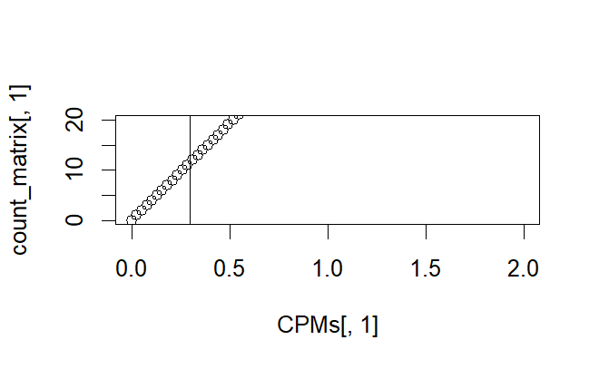

```r
# Let's have a look and see whether our threshold of 0.5 does indeed correspond to a count of about 10-15 by Plotting the expression profile of the first sample (First column)
plot(CPMs[,1],count_matrix[,1],ylim=c(0,20),xlim=c(0,2))
abline(v=0.3)
```

```r
counts_filtered <- as.data.frame(counts.keep)
head(counts_filtered)
```

|  | GTEX-WWYW-3126-SM-3NB39.1 | GTEX-WVLH-3026-SM-3MJG9.1 | GTEX-14BIM-3026-SM-7EWCY.1 | GTEX-16GPK-3026-SM-79ON9.1 | GTEX-18465-3026-SM-7LG6Y.1 | GTEX-1GN73-3126-SM-9KNTY.1 | GTEX-1LKK1-3126-SM-EWRNY.1 | GTEX-1R9K4-3126-SM-DTX9Y.1 | GTEX-13OW8-2826-SM-5L3GC.1 | GTEX-13VXU-2926-SM-5LU5C.1 | GTEX-144FL-3026-SM-5O99C.1 | GTEX-12WSA-2926-SM-5EQ4D.1 | GTEX-11DXY-3226-SM-5GIDE.1 | GTEX-13QIC-2926-SM-5J2NF.1 | GTEX-132Q8-3026-SM-5PNVG.1 | GTEX-13JVG-3126-SM-5L3FH.1 | GTEX-ZDXO-2126-SM-4WKFI.1 | GTEX-11ZUS-2926-SM-5FQSL.1 | GTEX-11EI6-3026-SM-5GZZO.1 | GTEX-11GSP-3226-SM-5986O.1 | GTEX-11TTK-2926-SM-5PNYP.1 | GTEX-12ZZW-2926-SM-5LZUP.1 | GTEX-13PVQ-3026-SM-5SI93.1 | GTEX-13O3Q-2926-SM-5KM45.1 | GTEX-11O72-2926-SM-5BC4V.1 | GTEX-11EMC-3226-SM-5EGKW.1 | GTEX-13OVJ-2826-SM-5L3GW.1 | GTEX-11OF3-2926-SM-5HL78.1 | GTEX-X585-3026-SM-46MWF.1 | … |
| --- | --- | --- | --- | --- | --- | --- | --- | --- | --- | --- | --- | --- | --- | --- | --- | --- | --- | --- | --- | --- | --- | --- | --- | --- | --- | --- | --- | --- | --- | --- |
| ENSG00000223972.5 | 3 | 4 | 4 | 7 | 8 | 7 | 8 | 2 | 15 | 5 | 9 | 16 | 8 | 6 | 11 | 7 | 1 | 8 | 28 | 9 | 6 | 14 | 18 | 6 | 13 | 9 | 5 | 31 | 12 | … |
| ENSG00000278267.1 | 32 | 20 | 36 | 15 | 23 | 17 | 31 | 22 | 22 | 16 | 29 | 29 | 22 | 21 | 23 | 15 | 19 | 28 | 18 | 11 | 14 | 23 | 16 | 16 | 35 | 23 | 20 | 38 | 21 | … |
| ENSG00000227232.5 | 707 | 632 | 878 | 402 | 636 | 706 | 732 | 551 | 641 | 657 | 778 | 669 | 707 | 545 | 725 | 437 | 726 | 738 | 511 | 494 | 577 | 635 | 737 | 496 | 812 | 653 | 742 | 1245 | 722 | … |
| ENSG00000243485.5 | 16 | 12 | 22 | 9 | 18 | 11 | 10 | 13 | 15 | 21 | 15 | 8 | 13 | 11 | 27 | 6 | 13 | 33 | 14 | 10 | 17 | 11 | 4 | 16 | 13 | 10 | 8 | 16 | 12 | … |
| ENSG00000239945.1 | 4 | 8 | 7 | 2 | 5 | 12 | 3 | 20 | 12 | 6 | 8 | 6 | 15 | 10 | 5 | 4 | 8 | 9 | 5 | 5 | 8 | 3 | 5 | 6 | 6 | 9 | 13 | 12 | 7 | … |
| ENSG00000238009.6 | 13 | 18 | 23 | 10 | 19 | 38 | 12 | 58 | 32 | 18 | 16 | 13 | 32 | 21 | 25 | 12 | 17 | 35 | 12 | 11 | 19 | 13 | 15 | 27 | 20 | 21 | 40 | 42 | 41 | … |

**Normalization for Composition Bias (TMM)**

While CPM normalization accounts for differences in sequencing depth (library size), it does not address **composition bias**. Composition bias occurs when a small number of highly expressed genes dominate the total pool of RNA in a library, artificially deflating the relative counts of all other genes.

We apply **TMM** normalization instead of **TPM** because:

- **TPM** is for comparing different genes **within** one sample (it corrects for gene length).
- **TMM** is for comparing the same gene **between** different samples (Healthy vs. Tumor). It corrects for **composition bias**, ensuring that a few highly expressed genes do not skew the results for the entire library.

```r
# Create DGEList object
dgeObj <- DGEList(counts = counts_filtered)
```

```r
# Calculate TMM normalization factors
dgeObj <- calcNormFactors(dgeObj, method = "TMM")
```

```r
# Check normalization factors (should be around 1)
head(dgeObj$samples)
```

|  | group | lib.size | norm.factors |
| --- | --- | --- | --- |
| GTEX-WWYW-3126-SM-3NB39.1 | 1 | 38473770 | 0.9999378 |
| GTEX-WVLH-3026-SM-3MJG9.1 | 1 | 38490361 | 0.9857536 |
| GTEX-14BIM-3026-SM-7EWCY.1 | 1 | 38359731 | 1.1103344 |
| GTEX-16GPK-3026-SM-79ON9.1 | 1 | 37799078 | 0.7714457 |
| GTEX-18465-3026-SM-7LG6Y.1 | 1 | 39141979 | 0.9712103 |
| GTEX-1GN73-3126-SM-9KNTY.1 | 1 | 37165898 | 0.9885296 |

### 4.1.2. Unsupervised Clustering

```r
logcounts_all <- cpm(dgeObj, log = TRUE)
pca_res <- prcomp(t(logcounts_all), scale. = TRUE)
pca_df <- as.data.frame(pca_res$x)

samples_gtex <- colnames(counts_gtex2)
samples_tcga <- colnames(counts_tcga2)

pca_df$Group <- c(rep("GTEx", length(samples_gtex)), rep("TCGA", length(samples_tcga)))
pca_df$SampleID <- rownames(pca_df)

pca_df$Sex <- c(
  md_gtex[samples_gtex, ]$gtex.sex %>% recode(`1` = "Male", `2` = "Female"),
  md_tcga[samples_tcga, ]$tcga.gdc_cases.demographic.gender %>% str_to_title()
)

pca_df$Age <- c(
  md_gtex[samples_gtex, ]$gtex.age,
  as.character(round(as.numeric(md_tcga[samples_tcga, ]$tcga.gdc_cases.diagnoses.age_at_diagnosis) / 365.25, 0))
)

pca_df$AvgQ <- c(md_gtex[samples_gtex, ]$recount_seq_qc.avgq,
                 md_tcga[samples_tcga, ]$recount_seq_qc.avgq)

# Variabile numerica per il menu a tendina
pca_df$AgeNumeric <- as.numeric(gsub("[^0-9]", "", pca_df$Age))
```

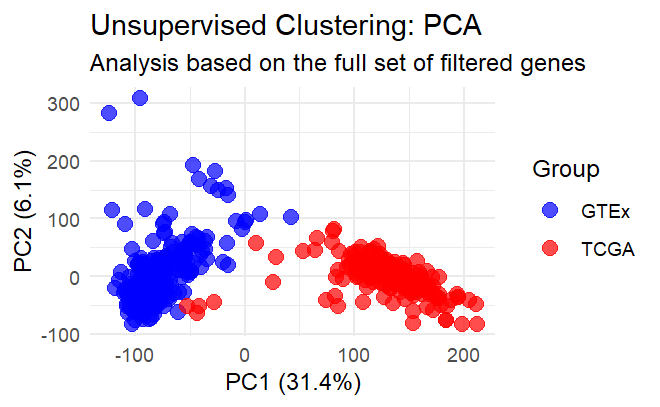

```r
ggplot(pca_df, aes(x = PC1, y = PC2, color = Group)) +
  geom_point(size = 3, alpha = 0.7) +
  theme_minimal() +
  scale_color_manual(values = c("GTEx" = "blue", "TCGA" = "red")) +
  labs(title = "Unsupervised Clustering: PCA",
       subtitle = "Analysis based on the full set of filtered genes",
       x = paste0("PC1 (", round(100*summary(pca_res)$importance[2,1], 1), "%)"),
       y = paste0("PC2 (", round(100*summary(pca_res)$importance[2,2], 1), "%)"))
```

```r
p_inter <- plot_ly(pca_df, x = ~PC1, y = ~PC2,
             symbol = ~Group,
             symbols = c('circle', 'x'),
             text = ~paste("Sample:", SampleID, "<br>Sex:", Sex, "<br>Age:", Age, "<br>AvgQ:", AvgQ),
             type = "scatter", mode = "markers",
             marker = list(size = 10, opacity = 0.8)) %>%
  layout(
    title = "Interactive PCA: Metadata Exploration",
    xaxis = list(title = "PC1"),
    yaxis = list(title = "PC2"),
    updatemenus = list(
      list(
        x = 0.05, y = 1, xanchor = "left", yanchor = "top",
        buttons = list(
          list(method = "restyle",
               args = list("marker.color", list(ifelse(pca_df$Group == "GTEx", "blue", "red"))),
               label = "Color by Dataset"),
          list(method = "restyle",
               args = list("marker.color", list(ifelse(pca_df$Sex == "Male", "#1f77b4", "#e377c2"))),
               label = "Color by Sex"),
          list(method = "restyle",
               args = list("marker.color", list(pca_df$AgeNumeric),
                           "marker.colorscale", "Viridis", "marker.showscale", TRUE),
               label = "Color by Age"),
          list(method = "restyle",
               args = list("marker.color", list(pca_df$AvgQ),
                           "marker.colorscale", "Plasma", "marker.showscale", TRUE),
               label = "Color by RNA Quality")
        )
      )
    )
  )

p_inter
```

[interactive chart not shown]

```r
# We estimate the variance for each row in the logcounts matrix
var_genes <- apply(logcounts_all, 1, var)

# Get the gene names for the top 100 most variable genes
select_var <- names(sort(var_genes, decreasing=TRUE))[1:100]

# Keep the expression values for the top 100 variable genes
highly_variable_lcpm <- logcounts_all[select_var,]
dim(highly_variable_lcpm)
```

```
[1] 100 461
```

[figure not shown]

```r
# Setup colors
mypalette <- brewer.pal(11,"RdYlBu")
morecols <- colorRampPalette(mypalette)

# Assign blue and red to different datasets
col.cell <- ifelse(pca_df$Group == "GTEx", "blue", "red")


heatmap.2(highly_variable_lcpm,
          col=rev(morecols(50)),
          trace="none",
          main="Top 100 most variable genes across samples",
          ColSideColors=col.cell,
          scale="row",
          labCol="",      # Hide sample names for clarity
          cexRow=0.6,     # Adjust gene name size
          srtCol=45
)

# Add Legend
legend("topright",
       legend = c("GTEx (Healthy)", "TCGA (Tumor)"),
       col = c("blue", "red"),
       lty = 1,
       lwd = 10,
       cex = 0.7)
```

```r
# We estimate the variance for each row in the logcounts matrix
var_genes <- apply(logcounts_all, 1, var)

# Get the gene names for the top 100 LEAST variable genes (lowest variance)
select_var_low <- names(sort(var_genes, decreasing = FALSE))[1:100]

# Keep the expression values for the top 100 least variable genes
least_variable_lcpm <- logcounts_all[select_var_low,]
dim(least_variable_lcpm)
```

```
[1] 100 461
```

[figure not shown]

```r
# Setup colors
mypalette <- brewer.pal(11,"RdYlBu")
morecols <- colorRampPalette(mypalette)

# Assign blue and red to different datasets
col.cell <- ifelse(pca_df$Group == "GTEx", "blue", "red")


heatmap.2(least_variable_lcpm,
          col=rev(morecols(50)),
          trace="none",
          main="Top 100 LEAST variable genes across samples",
          ColSideColors=col.cell,
          scale="row",
          labCol="",      # Hide sample names for clarity
          cexRow=0.6,     # Adjust gene name size
          srtCol=45
)

# Add Legend
legend("topright",
       legend = c("GTEx (Healthy)", "TCGA (Tumor)"),
       col = c("blue", "red"),
       lty = 1,
       lwd = 10,
       cex = 0.7)
```

## 4.2. DE Analysis

**Count the reads for any sample**

[figure not shown]

```r
idx_gtex <- 1:ncol(counts_gtex2)
idx_tcga <- (ncol(counts_gtex2) + 1):(ncol(counts_gtex2) + ncol(counts_tcga2))

lib_sizes_gtex <- dgeObj$samples$lib.size[idx_gtex]
names(lib_sizes_gtex) <- colnames(dgeObj)[idx_gtex]
low_10_gtex <- sort(lib_sizes_gtex)[1:10]

lib_sizes_tcga <- dgeObj$samples$lib.size[idx_tcga]
names(lib_sizes_tcga) <- colnames(dgeObj)[idx_tcga]
low_10_tcga <- sort(lib_sizes_tcga)[1:10]

low_20_total <- c(low_10_gtex, low_10_tcga)

par(mar = c(10, 4, 4, 2))
barplot(low_20_total / 1e6,
        las = 2,
        ylab = "Library size (millions)",
        main = "Bottom 10 Samples by Library Size (GTEx vs TCGA)",
        col = c(rep("blue", 10), rep("red", 10)),
        cex.names = 0.7) # Rimpicciolisce i nomi delle colonne per farli stare

legend("topleft", legend = c("GTEx (Lowest 10)", "TCGA (Lowest 10)"),
       fill = c("blue", "red"), bty = "n")
```

```r
NA
NA
```

*Plot the distribution of expression for sample*

```r
sample_means <- colMeans(CPMs)

idx_gtex <- 1:ncol(counts_gtex2)
idx_tcga <- (ncol(counts_gtex2) + 1):(ncol(counts_gtex2) + ncol(counts_tcga2))

low_10_gtex_names <- names(sort(sample_means[idx_gtex])[1:10])
low_10_tcga_names <- names(sort(sample_means[idx_tcga])[1:10])

logcounts <- cpm(count_matrix, log=TRUE)
sub_logcounts <- logcounts[, c(low_10_gtex_names, low_10_tcga_names)]
```

```r
par(mar = c(10, 4, 4, 2))
boxplot(sub_logcounts,
        las = 2,
        main = "Boxplot of Log2-CPMs (Bottom 10 Samples per Group)",
        ylab = "Log2 Counts per Million",
        col = c(rep("blue", 10), rep("red", 10)),
        names = c(paste0("GTEx_", 1:10), paste0("TCGA_", 1:10)))

abline(h = median(logcounts), col = "darkgreen", lwd = 2, lty = 2)
```

[figure not shown]

```r
legend("topright", legend = c("GTEx (Lowest Mean)", "TCGA (Lowest Mean)", "Global Median"),
       fill = c("blue", "red", NA), border = c("black", "black", NA),
       lty = c(NA, NA, 2), col = c(NA, NA, "darkgreen"), bty = "n")
```

### 4.2.1. Naive Approach

```r
# Save the normalized data into a new variable
simple_deg <- logcounts_all

# Gather the columns corresponding to the 2 groups
gtex_cols <- which(pca_df$Group == "GTEx")
tcga_cols <- which(pca_df$Group == "TCGA")
```

**Perform a t-test on the groups and optain the p-value**

```r
p_values <- apply(simple_deg, 1, function(x) {
  t.test(x[gtex_cols], x[tcga_cols])$p.value
})
```

**Calculate foldchange**

```r
log2FC <- rowMeans(simple_deg[, tcga_cols]) - rowMeans(simple_deg[, gtex_cols])
results_ttest <- data.frame(
  gene = rownames(simple_deg),
  log2FC = log2FC,
  p_value = p_values
)
results_ttest
```

|  | gene | log2FC | p_value |
| --- | --- | --- | --- |
| ENSG00000223972.5 | ENSG00000223972.5 | -7.585698e-01 | 5.099213e-21 |
| ENSG00000278267.1 | ENSG00000278267.1 | -1.807317e+00 | 1.842060e-82 |
| ENSG00000227232.5 | ENSG00000227232.5 | -8.146642e-01 | 1.404609e-53 |
| ENSG00000243485.5 | ENSG00000243485.5 | -1.356548e+00 | 1.756389e-59 |
| ENSG00000239945.1 | ENSG00000239945.1 | -6.657114e-01 | 8.717338e-22 |
| ENSG00000238009.6 | ENSG00000238009.6 | -1.092309e+00 | 8.763126e-52 |
| ENSG00000233750.3 | ENSG00000233750.3 | -5.298985e-01 | 2.261493e-14 |
| ENSG00000268903.1 | ENSG00000268903.1 | -1.490041e+00 | 4.081036e-42 |
| ENSG00000269981.1 | ENSG00000269981.1 | -1.237486e+00 | 4.069912e-34 |
| ENSG00000239906.1 | ENSG00000239906.1 | -9.431212e-01 | 7.323015e-42 |

[output cut: 990 more lines]

**Adjust p-values using Benjamini-Hochberg**

```r
results_ttest$adj_p <- p.adjust(results_ttest$p_value, method = "BH")

results_ttest$significant <- with(results_ttest,
                                  ifelse(adj_p < 0.01 & abs(log2FC) > 1, "Significant", "Non Significant"))
```

**Plot the result using vulgano plot**

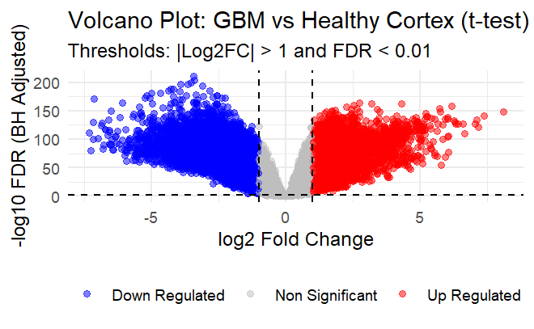

```r
results_ttest$direction <- with(results_ttest,
                                 ifelse(adj_p < 0.01 & log2FC > 1, "Up Regulated",
                                 ifelse(adj_p < 0.01 & log2FC < -1, "Down Regulated", "Non Significant")))

ggplot(results_ttest, aes(x = log2FC, y = -log10(adj_p), color = direction)) +
  geom_point(alpha = 0.5, size = 1.5) +
  scale_color_manual(values = c("Down Regulated" = "blue",
                                "Non Significant" = "grey",
                                "Up Regulated" = "red")) +
  theme_minimal() +

  geom_vline(xintercept = c(-1, 1), linetype = "dashed", color = "black") +
  geom_hline(yintercept = -log10(0.01), linetype = "dashed", color = "black") +


  labs(title = "Volcano Plot: GBM vs Healthy Cortex (t-test)",
       subtitle = "Thresholds: |Log2FC| > 1 and FDR < 0.01",
       x = "log2 Fold Change",
       y = "-log10 FDR (BH Adjusted)") +

  theme(legend.title = element_blank(),
        legend.position = "bottom")
```

### 4.2.2. EdgeR Approach

The use of generalized linear models (GLMs) in edgeR allows us to model biological variability (overdispersion) inherent in RNA-seq data, overcoming the limitations of simple t-tests.

**Create a Design Matrix**

The design matrix defines the mathematical framework for the statistical comparison. In our case, we compare the tumor group (TCGA) against the healthy baseline (GTEx).

```r
# 1. Initialize DGEList object
dgeObj <- DGEList(counts = count_matrix)

# 2. Assign groups and filter lowly expressed genes
group <- factor(pca_df$Group, levels = c("GTEx", "TCGA"))
dgeObj$samples$group <- group

keep <- filterByExpr(dgeObj, group = group, min.count = 50, min.prop = 0.4)
dgeObj <- dgeObj[keep, , keep.lib.sizes = FALSE]

# 3. Normalization and Design Matrix
dgeObj <- calcNormFactors(dgeObj, method = "TMM")
design <- model.matrix(~ group)
colnames(design) <- c("Intercept", "TCGA_vs_GTEx")

# Print the design matrix structure (first few rows)
print("Design Matrix (Head):")
```

```
[1] "Design Matrix (Head):"
```

```r
print(head(design))
```

```
  Intercept TCGA_vs_GTEx
1         1            0
2         1            0
3         1            0
4         1            0
5         1            0
6         1            0
```

```r
# Print the number of genes remaining after filtering
print(paste("Number of genes after filtering:", nrow(dgeObj)))
```

```
[1] "Number of genes after filtering: 20374"
```

**Dispersion Estimation**

Estimating dispersion is a crucial step to distinguish true biological signal from random technical noise.

```r
# 1. Estimate Common Dispersion (Usually fast)
print("Estimating common dispersion...")
```

```
[1] "Estimating common dispersion..."
```

```r
dgeObj <- estimateCommonDisp(dgeObj, design)

# 2. Estimate Trended Dispersion (This is what usually takes time)
print("Estimating trended dispersion...")
```

```
[1] "Estimating trended dispersion..."
```

```r
dgeObj <- estimateGLMTrendedDisp(dgeObj, design)

# 3. Estimate Tagwise Dispersion (Final step)
print("Estimating tagwise dispersion...")
```

```
[1] "Estimating tagwise dispersion..."
```

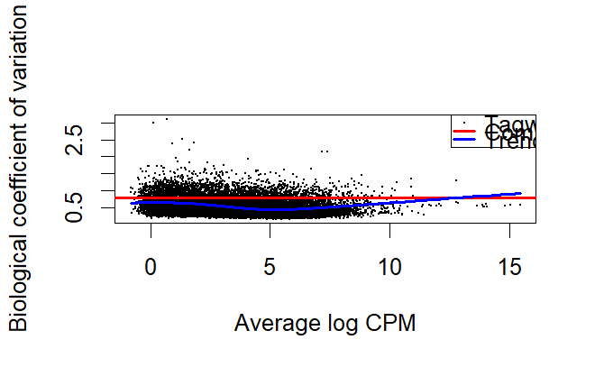

```r
dgeObj <- estimateGLMTagwiseDisp(dgeObj, design)


# Visualize the BCV
plotBCV(dgeObj)
```

**GLM Fitting and Likelihood Ratio Test (LRT)**

```r
# Now that dispersions are estimated, we can fit the model
fit <- glmFit(dgeObj, design)
lrt <- glmLRT(fit, coef = 2)

# 6. Extract results
results_edgeR <- as.data.frame(topTags(lrt, n = Inf))
results_edgeR$is_significant <- results_edgeR$FDR < 0.05 & abs(results_edgeR$logFC) > 1

head(results_edgeR)
```

|  | logFC | logCPM | LR | PValue | FDR | is_significant |
| --- | --- | --- | --- | --- | --- | --- |
| ENSG00000128713.13 | 8.857372 | 0.7035581 | 1555.702 | 0 | 0 | TRUE |
| ENSG00000128710.5 | 8.596491 | 1.4806595 | 1532.286 | 0 | 0 | TRUE |
| ENSG00000254369.6 | 8.293539 | 2.0756228 | 1530.420 | 0 | 0 | TRUE |
| ENSG00000131747.14 | 7.823778 | 4.9688677 | 1844.843 | 0 | 0 | TRUE |
| ENSG00000101057.15 | 7.753607 | 3.5942694 | 2747.385 | 0 | 0 | TRUE |
| ENSG00000168078.9 | 7.739282 | 2.9408702 | 2603.396 | 0 | 0 | TRUE |

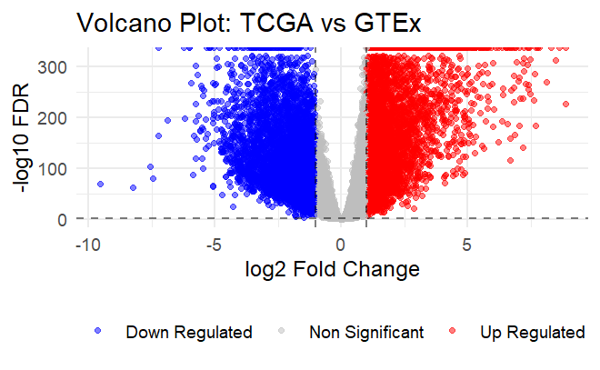

```r
# Extract results (using 'lrt' instead of 'lrt.BvsL')
results_edgeR <- as.data.frame(topTags(lrt, n = Inf))

# Add significance labels
results_edgeR$direction <- with(results_edgeR,
                                 ifelse(FDR < 0.01 & logFC > 1, "Up Regulated",
                                 ifelse(FDR < 0.01 & logFC < -1, "Down Regulated",
                                 "Non Significant")))

# Create Volcano Plot
ggplot(results_edgeR, aes(x = logFC, y = -log10(FDR), color = direction)) +
  geom_point(alpha = 0.5, size = 1.2) +
  scale_color_manual(values = c("Non Significant" = "grey",
                                "Up Regulated" = "red",
                                "Down Regulated" = "blue")) +
  theme_minimal() +
  # Add threshold lines
  geom_vline(xintercept = c(-1, 1), linetype = "dashed", alpha = 0.5) +
  geom_hline(yintercept = -log10(0.01), linetype = "dashed", alpha = 0.5) +
  labs(title = "Volcano Plot: TCGA vs GTEx",
       x = "log2 Fold Change",
       y = "-log10 FDR") +
  theme(legend.position = "bottom", legend.title = element_blank())
```

**Retrieve Gene Names**

```r
# Convert results to dataframe
results <- as.data.frame(topTags(lrt, n = Inf))

# Clean Ensembl IDs by removing version suffix
clean_ids <- gsub("\\..*", "", rownames(results))

# Map IDs to SYMBOL
results$SYMBOL <- mapIds(org.Hs.eg.db,
                         keys = clean_ids,
                         column = "SYMBOL",
                         keytype = "ENSEMBL",
                         multiVals = "first")

# Map IDs to GENENAME
results$GENENAME <- mapIds(org.Hs.eg.db,
                           keys = clean_ids,
                           column = "GENENAME",
                           keytype = "ENSEMBL",
                           multiVals = "first")

# Check the first few rows of the annotated results
head(results)
```

|  | logFC | logCPM | LR | PValue | FDR | SYMBOL | GENENAME |
| --- | --- | --- | --- | --- | --- | --- | --- |
| ENSG00000128713.13 | 8.857372 | 0.7035581 | 1555.702 | 0 | 0 | HOXD11 | homeobox D11 |
| ENSG00000128710.5 | 8.596491 | 1.4806595 | 1532.286 | 0 | 0 | HOXD10 | homeobox D10 |
| ENSG00000254369.6 | 8.293539 | 2.0756228 | 1530.420 | 0 | 0 | HOXA-AS3 | HOXA cluster antisense RNA 3 |
| ENSG00000131747.14 | 7.823778 | 4.9688677 | 1844.843 | 0 | 0 | TOP2A | DNA topoisomerase II alpha |
| ENSG00000101057.15 | 7.753607 | 3.5942694 | 2747.385 | 0 | 0 | MYBL2 | MYB proto-oncogene like 2 |
| ENSG00000168078.9 | 7.739282 | 2.9408702 | 2603.396 | 0 | 0 | PBK | PDZ binding kinase |

**Find the gene symbols of the genes tested**

```r
# Map IDs to gene names (SYMBOL and GENENAME) for all tested genes
gene_annotations <- AnnotationDbi::select(org.Hs.eg.db,
                                          keys = gsub("\\..*", "", rownames(dgeObj)),
                                          columns = c("SYMBOL", "GENENAME"),
                                          keytype = "ENSEMBL")

# View the result
head(gene_annotations)
```

|  | ENSEMBL | SYMBOL | GENENAME |
| --- | --- | --- | --- |
| 1 | ENSG00000227232 | NA | NA |
| 2 | ENSG00000268903 | NA | NA |
| 3 | ENSG00000269981 | NA | NA |
| 4 | ENSG00000241860 | NA | NA |
| 5 | ENSG00000279457 | NA | NA |
| 6 | ENSG00000241670 | NA | NA |

**Overlapping set of DEGs (Upset Plot)**

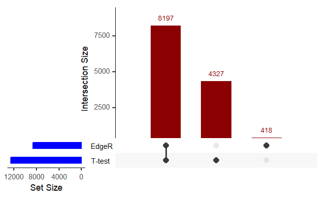

```r
# filter the 2 datsets for log2fc and pvalue
de_ttest <- results_ttest[abs(results_ttest$log2FC) > 1 & results_ttest$adj_p < 0.01, ]
de_edgeR <- results[abs(results$logFC) > 1 & results$FDR < 0.01, ]
genes_ttest <- de_ttest$gene
genes_edgeR <- rownames(de_edgeR)
gene_lists <- list("T-test" = genes_ttest, "EdgeR" = genes_edgeR)

# Produce the UpSet plot to visualize consistency
UpSetR::upset(UpSetR::fromList(gene_lists),
              nsets = 2,
              order.by = "freq",
              main.bar.color = "darkred",
              sets.bar.color = "blue")
```

**Function enrichment analysis on the genes we obtain through edgeR**

[figure not shown]

```r
upregulated_edgeR <- rownames(results[results$FDR < 0.05 & results$logFC > 1, ])
upregulated_clean <- gsub("\\..*", "", upregulated_edgeR)

# Perform GO enrichment analysis
ego <- enrichGO(gene          = upregulated_clean,
                OrgDb         = org.Hs.eg.db,
                keyType       = "ENSEMBL",
                ont           = "BP",
                pAdjustMethod = "BH",
                pvalueCutoff  = 0.05,
                qvalueCutoff  = 0.2,
                readable      = TRUE)

# View the results
dotplot(ego, showCategory=10)
```

**Visualize same results with the network**

[figure not shown]

```r
ora_analysis_bp <- pairwise_termsim(ego, method = "JC")
emapplot(ora_analysis_bp, color = "qvalue")
```

# 5. Protein-Protein Interaction (PPI) Network analysis

### Rationale

Genes do not act in isolation, but their protein products interact in complex networks to carry out cellular functions. Differential gene expression analysis identifies genes associated with the disease condition, but does not provide information on how these genes interact at the protein level.

Protein–Protein Interaction (PPI) networks allow the integration of transcriptomic results with proteomic knowledge, enabling the identification of key proteins (hubs), functional modules, and dysregulated biological pathways involved in the disease. This network-based approach follows the principles of network medicine, where disease-associated genes tend to cluster into connected subnetworks (disease modules).

```r
library(STRINGdb)
library(igraph)
library(clusterProfiler)
library(org.Hs.eg.db)
library(enrichplot)
library(tidyverse)
```

```r
deg_idx <- which(
  results_edgeR$FDR < 0.05 &
  abs(results_edgeR$logFC) > 1
)

deg_genes <- rownames(results_edgeR)[deg_idx]

length(deg_genes)
```

```
[1] 8615
```

```r
head(deg_genes)
```

```
[1] "ENSG00000128713.13" "ENSG00000128710.5"  "ENSG00000254369.6"  "ENSG00000131747.14" "ENSG00000101057.15"
[6] "ENSG00000168078.9"
```

Differentially expressed genes were selected using an edgeR-based analysis, applying a false discovery rate (FDR) threshold of 0.05 and an absolute log2 fold change greater than 1.

```r
deg_genes_clean <- sub("\\..*$", "", deg_genes)
head(deg_genes_clean)
```

```
[1] "ENSG00000128713" "ENSG00000128710" "ENSG00000254369" "ENSG00000131747" "ENSG00000101057" "ENSG00000168078"
```

Gene identifiers were originally annotated using Ensembl IDs including version numbers. Version information was removed to ensure compatibility with downstream annotation databases.

```r
gene_mapping <- bitr(
  deg_genes_clean,
  fromType = "ENSEMBL",
  toType   = "SYMBOL",
  OrgDb    = org.Hs.eg.db
)

head(gene_mapping)
```

|  | ENSEMBL | SYMBOL |
| --- | --- | --- |
| 1 | ENSG00000128713 | HOXD11 |
| 2 | ENSG00000128710 | HOXD10 |
| 3 | ENSG00000254369 | HOXA-AS3 |
| 4 | ENSG00000131747 | TOP2A |
| 5 | ENSG00000101057 | MYBL2 |
| 6 | ENSG00000168078 | PBK |

```r
deg_symbols <- unique(gene_mapping$SYMBOL)

length(deg_symbols)
```

```
[1] 7066
```

```r
head(deg_symbols)
```

```
[1] "HOXD11"   "HOXD10"   "HOXA-AS3" "TOP2A"    "MYBL2"    "PBK"
```

Ensembl gene identifiers were converted to gene symbols prior to PPI network construction. Genes that could not be mapped were excluded from downstream analyses.

```r
string_db <- STRINGdb$new(
  version = "11.5",
  species = 9606,
  score_threshold = 700,
  input_directory = ""
)
```

```r
mapped_genes <- string_db$map(
  data.frame(gene = deg_symbols),
  "gene",
  removeUnmappedRows = TRUE
)
nrow(mapped_genes)
```

```
[1] 6099
```

```r
head(mapped_genes)
```

|  | gene | STRING_id |
| --- | --- | --- |
| 1 | HOXD11 | 9606.ENSP00000249504 |
| 2 | HOXD10 | 9606.ENSP00000249501 |
| 3 | TOP2A | 9606.ENSP00000411532 |
| 4 | MYBL2 | 9606.ENSP00000217026 |
| 5 | PBK | 9606.ENSP00000428489 |
| 6 | HOXA6 | 9606.ENSP00000222728 |

### PPI Construction

```r
ppi_edges <- string_db$get_interactions(mapped_genes$STRING_id)
ppi_graph <- graph_from_data_frame(
  ppi_edges[, c("from", "to")],
  directed = FALSE
)
```

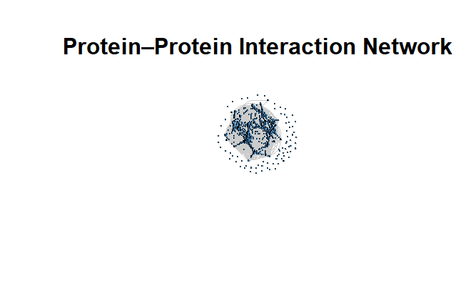

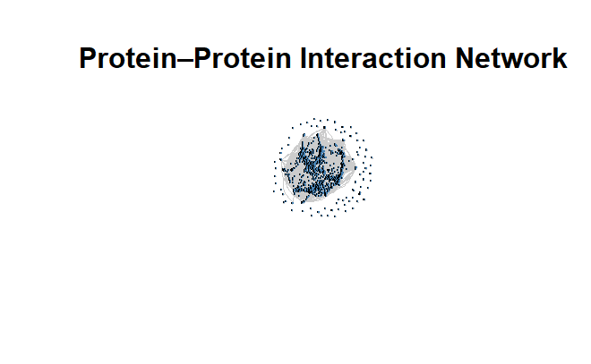

```r
plot(
  ppi_graph,
  vertex.label = NA,
  vertex.size = 3,
  edge.color = "grey80",
  vertex.color = "steelblue",
  main = "Protein–Protein Interaction Network"
)
```

The resulting PPI network is represented as an undirected graph, where nodes correspond to proteins and edges represent protein–protein interactions.

```r
deg <- degree(ppi_graph)
bet <- betweenness(ppi_graph)
```

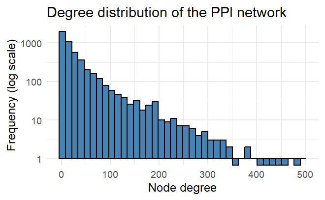

```r
deg_df <- data.frame(degree = deg)

ggplot(deg_df, aes(x = degree)) +
  geom_histogram(bins = 40, fill = "steelblue", color = "black") +
  scale_y_log10() +
  theme_minimal() +
  labs(
    title = "Degree distribution of the PPI network",
    x = "Node degree",
    y = "Frequency (log scale)"
  )
```

The right-skewed degree distribution indicates a scale-free topology, a common property of biological interaction networks characterized by the presence of highly connected hub proteins.

```r
top_hubs <- sort(deg, decreasing = TRUE)[1:10]
top_hubs
```

```
9606.ENSP00000269305 9606.ENSP00000378699 9606.ENSP00000344456 9606.ENSP00000274026 9606.ENSP00000256442
                 496                  466                  392                  388                  380
9606.ENSP00000275493 9606.ENSP00000383118 9606.ENSP00000400175 9606.ENSP00000302530 9606.ENSP00000349960
                 372                  342                  342                  336                  334
```

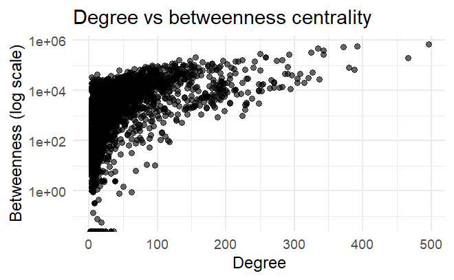

```r
centrality_df <- data.frame(
  protein = names(deg),
  degree = deg,
  betweenness = bet
)

ggplot(centrality_df, aes(x = degree, y = betweenness)) +
  geom_point(alpha = 0.6) +
  scale_y_log10() +
  theme_minimal() +
  labs(
    title = "Degree vs betweenness centrality",
    x = "Degree",
    y = "Betweenness (log scale)"
  )
```

While hub proteins are characterized by a high number of interactions, proteins with high betweenness centrality act as connectors between different regions of the network and may coordinate distinct functional modules.

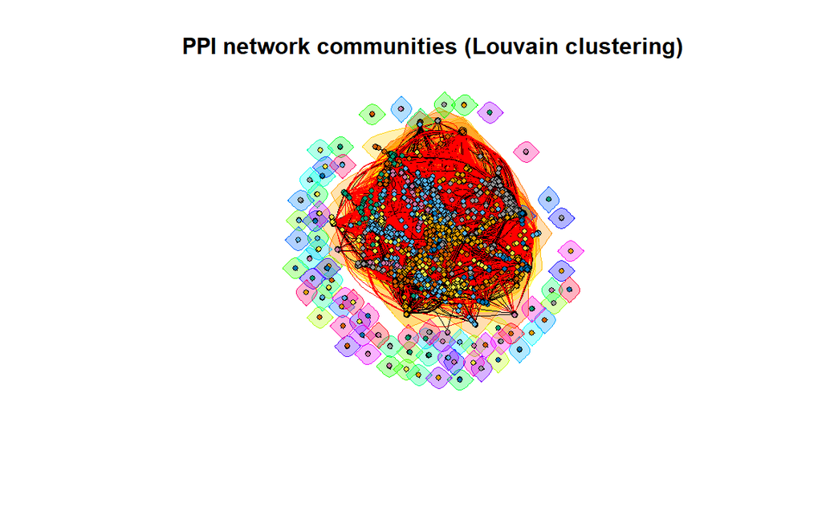

[figure not shown]

```r
communities <- cluster_louvain(ppi_graph)

plot(
  communities,
  ppi_graph,
  vertex.label = NA,
  vertex.size = 4,
  main = "PPI network communities (Louvain clustering)"
)
```

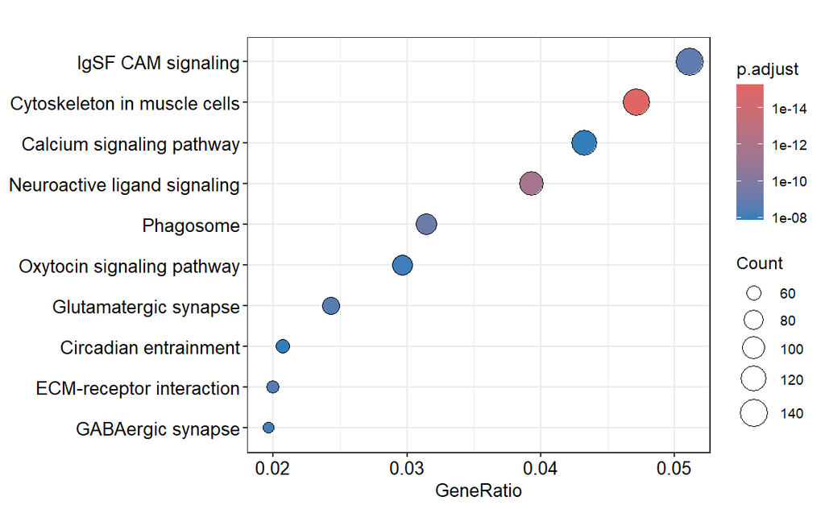

```r
entrez_ids <- bitr(
  mapped_genes$gene,
  fromType = "SYMBOL",
  toType = "ENTREZID",
  OrgDb = org.Hs.eg.db
)

kegg_enrich <- enrichKEGG(
  gene = entrez_ids$ENTREZID,
  organism = "hsa",
  pvalueCutoff = 0.05
)

dotplot(kegg_enrich, showCategory = 10)
```

Functional enrichment analysis of the PPI network revealed significant over-representation of signaling pathways related to cell communication, calcium signaling, and extracellular matrix interactions. Although some KEGG pathways are annotated as neuronal, they include general signaling components such as receptors and ion channels that are also active in non-neuronal tissues, including cancer. Overall, these results support the biological relevance of the identified PPI network and highlight dysregulated signaling processes associated with the disease.

```r
components_ppi <- components(ppi_graph)

table(components_ppi$csize)[1:5]
```

```
   2    3    4 4720 <NA>
  59   12    3    1
```

```r
largest_comp_size <- max(components_ppi$csize)
largest_comp_size
```

```
[1] 4720
```

Most proteins in the PPI network belong to a single large connected component, suggesting the presence of a coherent disease-associated module rather than isolated interactions.

```r
network_density <- edge_density(ppi_graph)
avg_degree <- mean(deg)

network_density
```

```
[1] 0.006234595
```

```r
avg_degree
```

```
[1] 30.456
```

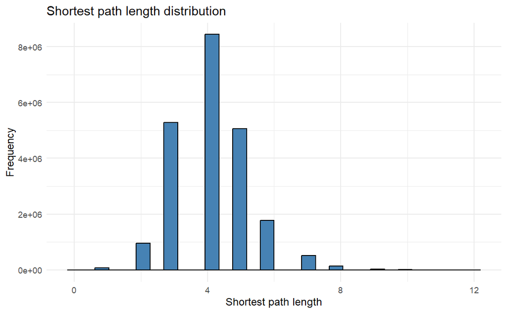

```r
lcc <- induced_subgraph(
  ppi_graph,
  V(ppi_graph)[components_ppi$membership ==
               which.max(components_ppi$csize)]
)
# Matrice delle distanze (igraph)
dist_mat <- igraph::distances(lcc)

# Converto in vettore, tolgo Inf/NA, poi costruisco il data.frame
dist_vec <- as.vector(dist_mat)
dist_vec <- dist_vec[is.finite(dist_vec)]

dist_df <- data.frame(distance = dist_vec)

ggplot(dist_df, aes(x = distance)) +
  geom_histogram(bins = 30, fill = "steelblue", color = "black") +
  theme_minimal() +
  labs(
    title = "Shortest path length distribution",
    x = "Shortest path length",
    y = "Frequency"
  )
```

# 6. Single-Cell RNA-seq Analysis

## 6.1. Introduction

To complement our bulk RNA-seq analysis comparing healthy brain cortex (GTEx) with glioblastoma (TCGA), we now perform single-cell RNA-seq analysis. This allows us to:

- Identify specific cell types present in brain cortex tissue
- Examine cell-type-specific expression patterns
- Validate bulk RNA-seq findings at cellular resolution
- Discover heterogeneous cell populations in the brain

## 6.2. Package Installation and Loading

```r
# Install required packages (run once)
if (!requireNamespace("BiocManager", quietly = TRUE))
    install.packages("BiocManager")

packages <- c("scRNAseq", "SingleCellExperiment", "Seurat", "SeuratData")
install_if_missing <- function(pkg) {
  if (!requireNamespace(pkg, quietly = TRUE)) {
    BiocManager::install(pkg, ask = FALSE)
  }
}
lapply(packages, install_if_missing)
```

```
[[1]]
NULL

[[2]]
NULL

[[3]]
NULL

[[4]]
[1] "SeuratData"
```

```r
# Load libraries
library(scRNAseq)
library(Seurat)
library(SingleCellExperiment)
library(dplyr)      # For data manipulation
library(ggplot2)    # For plotting
library(patchwork)  # For combining plots (needed for p1 + p2 + p3)
```

## 6.3. Search and Load Brain Cortex Dataset

### 6.3.1. Search for Brain/Cortex Datasets

```r
# Search for cortex-related datasets
brain_datasets <- searchDatasets("cortex")
cat("Brain/Cortex datasets available:\n")
```

```
Brain/Cortex datasets available:
```

```r
print(brain_datasets[, c("name", "title", "version", "path", "description")])
```

```
DataFrame with 8 rows and 5 columns
                    name                  title     version        path
             <character>            <character> <character> <character>
1         hu-cortex-2017 Dissecting cell-type..  2023-12-20      cortex
2       tasic-brain-2016 Adult mouse cortical..  2024-04-18          NA
3  zhong-prefrontal-2018 A single-cell RNA-se..  2023-12-22          NA
4 nowakowski-cortex-2017 Spatiotemporal gene ..  2023-12-22          NA
5                 legacy Adult mouse cortical..  2023-12-18       allen
6                 legacy Low-coverage single-..  2023-12-18    fluidigm
7      zeisel-brain-2015 Brain structure. Cel..  2023-12-14          NA
8  bhaduri-organoid-2020 Cell stress in corti..  2023-12-21          NA
             description
             <character>
1 Dissecting cell-type..
2 Adult mouse cortical..
3 A single-cell RNA-se..
4 Spatiotemporal gene ..
5 Adult mouse cortical..
6 Low-coverage single-..
7 Brain structure. Cel..
8 Cell stress in corti..
```

### 6.3.2. Select Dataset

```r
# Check available paths for this dataset
name <- "hu-cortex-2017"
version <- "2023-12-20"

cat("Available paths for", name, ":\n")
```

```
Available paths for hu-cortex-2017 :
```

```r
available_paths <- listPaths(name, version)
print(available_paths)
```

```
[1] "3T3"    "cortex"
```

### 6.3.3. Download and Load Dataset

```r
# Fetch the dataset
path = "cortex"
cortex_sc <- fetchDataset(name,version,path)
cortex_sc
```

```
class: SingleCellExperiment
dim: 19936 42500
metadata(0):
assays(1): counts
rownames(19936): 0610006L08Rik 0610007P14Rik ... mt-Tm n-R5-8s1
rowData names(0):
colnames(42500): ATTGTAATAAGC ACTTGTCCCAGG ... AGGTTCACGTAA TGTGAGAAGGAA
colData names(2): treatment animal
reducedDimNames(0):
mainExpName: NULL
altExpNames(0):
```

```r
# Display dataset information
cat("\n=== Dataset Loaded Successfully ===\n")
```

```
=== Dataset Loaded Successfully ===
```

```r
print(cortex_sc)
```

```
class: SingleCellExperiment
dim: 19936 42500
metadata(0):
assays(1): counts
rownames(19936): 0610006L08Rik 0610007P14Rik ... mt-Tm n-R5-8s1
rowData names(0):
colnames(42500): ATTGTAATAAGC ACTTGTCCCAGG ... AGGTTCACGTAA TGTGAGAAGGAA
colData names(2): treatment animal
reducedDimNames(0):
mainExpName: NULL
altExpNames(0):
```

```r
cat("\nNumber of genes:", nrow(cortex_sc), "\n")
```

```
Number of genes: 19936
```

```r
cat("Number of cells:", ncol(cortex_sc), "\n")
```

```
Number of cells: 42500
```

## 6.4. Explore Dataset Metadata

```r
# View available metadata columns
cat("Available metadata columns:\n")
```

```
Available metadata columns:
```

```r
metadata_cols <- colnames(colData(cortex_sc))
print(metadata_cols)
```

```
[1] "treatment" "animal"
```

```r
# Display metadata content
cat("\nMetadata content:\n")
```

```
Metadata content:
```

```r
head(colData(cortex_sc))
```

```
DataFrame with 6 rows and 2 columns
               treatment    animal
             <character> <integer>
ATTGTAATAAGC          NA         1
ACTTGTCCCAGG          NA         1
CCACCTTTTAAN          NA         1
ACAGAAATATCA          NA         1
CCACCCAACTGN          NA         1
CCAGTCGTATAN          NA         1
```

### 6.4.1. Metadata Summary

```r
cat("=== Dataset Metadata Summary ===\n\n")
```

```
=== Dataset Metadata Summary ===
```

```r
cat("Available columns:", length(metadata_cols), "\n")
```

```
Available columns: 2
```

```r
cat("Columns:", paste(metadata_cols, collapse = ", "), "\n\n")
```

```
Columns: treatment, animal
```

```r
# Check protocol column
if("protocol" %in% metadata_cols) {
  cat("Protocol values:\n")
  print(table(cortex_sc$protocol))
}

cat("\n**Note:** This dataset does not include pre-annotated cell types.\n")
```

```
**Note:** This dataset does not include pre-annotated cell types.
```

```r
cat("We will identify cell types through unsupervised clustering and marker gene analysis.\n")
```

```
We will identify cell types through unsupervised clustering and marker gene analysis.
```

### 6.4.2. Basic Data Quality Metrics

```r
print(cortex_sc)
```

```
class: SingleCellExperiment
dim: 19936 42500
metadata(0):
assays(1): counts
rownames(19936): 0610006L08Rik 0610007P14Rik ... mt-Tm n-R5-8s1
rowData names(0):
colnames(42500): ATTGTAATAAGC ACTTGTCCCAGG ... AGGTTCACGTAA TGTGAGAAGGAA
colData names(2): treatment animal
reducedDimNames(0):
mainExpName: NULL
altExpNames(0):
```

```r
cat("\nNumber of genes:", nrow(cortex_sc), "\n")
```

```
Number of genes: 19936
```

```r
cat("Number of cells:", ncol(cortex_sc), "\n")
```

```
Number of cells: 42500
```

## 6.5. Prepare Data for Seurat

Objective

The scRNA-seq dataset was downloaded as a SingleCellExperiment object. Before performing downstream single-cell analysis (normalization, dimensionality reduction, clustering), the data must be converted into a Seurat object, which requires:

A standard sparse count matrix

Unique gene (feature) names

Unique cell identifiers

```r
# List available assays
assays(cortex_sc)
```

```
List of length 1
names(1): counts
```

```r
# Access the raw counts matrix
assay(cortex_sc, "counts")
```

```
<19936 x 42500> sparse DelayedMatrix object of type "integer":
              ATTGTAATAAGC ACTTGTCCCAGG CCACCTTTTAAN ACAGAAATATCA ... ATTCGACGATTC ATGTACTGCGGG AGGTTCACGTAA TGTGAGAAGGAA
0610006L08Rik            0            0            0            0   .            0            0            0            0
0610007P14Rik            3            0            0            1   .            0            0            0            1
0610009B22Rik            0            0            1            0   .            0            0            0            0
0610009E02Rik            0            0            0            0   .            0            0            0            0
0610009L18Rik            0            0            0            0   .            0            0            0            0
          ...            .            .            .            .   .            .            .            .            .
       mt-Nd6            0            0            0            0   .            0            0            0            0
      mt-Rnr1            0            1            0            0   .            1            0            0            0
      mt-Rnr2            5            8           10            8   .            4            2            1            0
        mt-Tm            0            0            0            0   .            0            0            0            0
     n-R5-8s1            1            3            1            0   .            0            0            0            0
```

### 6.5.2 Inspect dataset metadata

```r
colnames(colData(cortex_sc))
```

```
[1] "treatment" "animal"
```

```r
colnames(rowData(cortex_sc))
```

```
character(0)
```

```r
head(rowData(cortex_sc))
```

```
DataFrame with 6 rows and 0 columns
```

No gene-level metadata is provided (rowData is empty), meaning gene identifiers are stored directly as row names in the count matrix.

### 6.5.3 Extract and standardize the count matrix

```r
# Extract raw counts
counts <- assay(cortex_sc, "counts")

# Convert to standard sparse matrix
counts <- as(counts, "dgCMatrix")
```

### 6.5.4 Ensure unique gene and cell identifiers

```r
# Make feature (gene) names unique
rownames(counts) <- make.unique(rownames(counts))

# Make cell names unique
colnames(counts) <- make.unique(colnames(counts))
```

### 6.5.5 Create the Seurat object

```r
so <- CreateSeuratObject(
  counts = counts,
  project = "hu_cortex_2017_cortex"
)

so
```

```
An object of class Seurat
19936 features across 42500 samples within 1 assay
Active assay: RNA (19936 features, 0 variable features)
 1 layer present: counts
```

### 6.5.6 Add cell-level metadata

```r
meta <- as.data.frame(colData(cortex_sc))
rownames(meta) <- colnames(counts)

so <- AddMetaData(so, metadata = meta)

head(so@meta.data)
```

|  | orig.ident | nCount_RNA | nFeature_RNA | treatment | animal |
| --- | --- | --- | --- | --- | --- |
| ATTGTAATAAGC | hu_cortex_2017_cortex | 21015 | 5579 | NA | 1 |
| ACTTGTCCCAGG | hu_cortex_2017_cortex | 25129 | 5441 | NA | 1 |
| CCACCTTTTAAN | hu_cortex_2017_cortex | 25437 | 5463 | NA | 1 |
| ACAGAAATATCA | hu_cortex_2017_cortex | 28982 | 5910 | NA | 1 |
| CCACCCAACTGN | hu_cortex_2017_cortex | 18527 | 4834 | NA | 1 |
| CCAGTCGTATAN | hu_cortex_2017_cortex | 24947 | 5805 | NA | 1 |

```r
NA
NA
```

## 6.6. Quality Control and Filtering

### 6.6.1. Calculate QC Metrics

```r
# Calculate percentage of mitochondrial genes
so[["percent.mt"]] <- PercentageFeatureSet(so, pattern = "^MT-")

# View updated metadata
head(so@meta.data)
```

|  | orig.ident | nCount_RNA | nFeature_RNA | treatment | animal | percent.mt |
| --- | --- | --- | --- | --- | --- | --- |
| ATTGTAATAAGC | hu_cortex_2017_cortex | 21015 | 5579 | NA | 1 | 0 |
| ACTTGTCCCAGG | hu_cortex_2017_cortex | 25129 | 5441 | NA | 1 | 0 |
| CCACCTTTTAAN | hu_cortex_2017_cortex | 25437 | 5463 | NA | 1 | 0 |
| ACAGAAATATCA | hu_cortex_2017_cortex | 28982 | 5910 | NA | 1 | 0 |
| CCACCCAACTGN | hu_cortex_2017_cortex | 18527 | 4834 | NA | 1 | 0 |
| CCAGTCGTATAN | hu_cortex_2017_cortex | 24947 | 5805 | NA | 1 | 0 |

### 6.6.2. Visualize QC Metrics

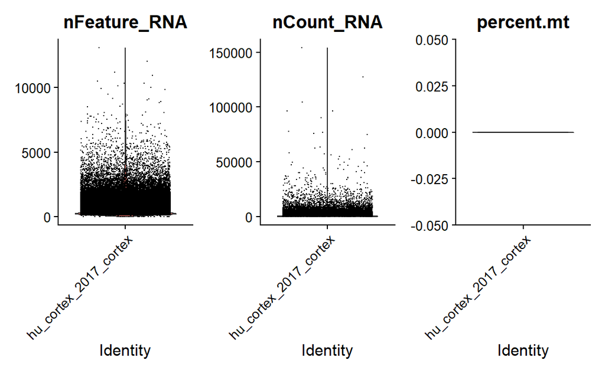

```r
# Violin plots for quality control metrics
VlnPlot(so, features = c("nFeature_RNA", "nCount_RNA", "percent.mt"),
        ncol = 3, pt.size = 0.1)
```

### 6.6.3. Feature Scatter Plots

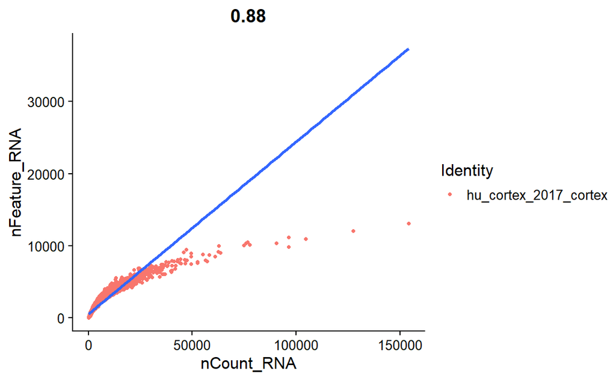

```r
library(ggplot2)
# Scatter plot to examine relationship between total counts and detected genes
FeatureScatter(so, feature1 = "nCount_RNA", feature2 = "nFeature_RNA") +
  geom_smooth(method = "lm")
```

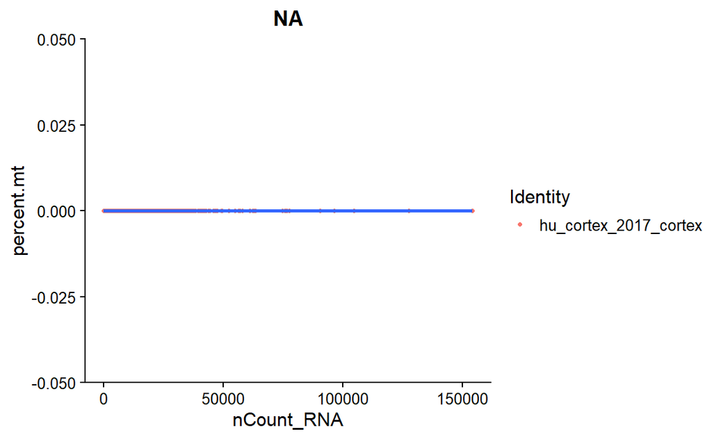

```r
# Scatter plot for mitochondrial content vs gene count
FeatureScatter(so, feature1 = "nCount_RNA", feature2 = "percent.mt") +
  geom_smooth(method = "lm")
```

### 6.6.4. Filter Cells

```r
# Filter based on QC metrics
# Adjust thresholds based on your violin plots
so <- subset(so, subset = nFeature_RNA > 200 &
                          nFeature_RNA < 2500 &
                          percent.mt < 5)

cat("Cells after filtering:", ncol(so), "\n")
```

```
Cells after filtering: 34291
```

```r
cat("Genes:", nrow(so), "\n")
```

```
Genes: 19936
```

## 6.7. Normalization

Normalize the raw gene expression data to enable meaningful comparison between cells. The `NormalizeData()` function applies log-normalization:

$$\text{Normalized}_{ij} = \log_1p \left(
\frac{\text{Counts}_{ij}}{\sum_{k} \text{Counts}_{kj}} \times 10000
\right)$$

This corrects for differences in sequencing depth between cells while preserving biological differences.

```r
# Log-normalize the data
so <- NormalizeData(so,
                    normalization.method = "LogNormalize",
                    scale.factor = 10000)
cat("Normalization complete.\n")
```

```
Normalization complete.
```

```r
cat("Normalized data stored in 'data' layer.\n")
```

```
Normalized data stored in 'data' layer.
```

## 6.8. Identify Highly Variable Features

Identify genes that show high cell-to-cell variation. These genes are most informative for distinguishing cell types and will be used for downstream analysis.

```r
# Find variable features using variance stabilizing transformation
so <- FindVariableFeatures(so,
                           selection.method = "vst",
                           nfeatures = 2000)
# Identify the top 10 most variable genes
top10_var <- head(VariableFeatures(so), 10)
cat("Top 10 most variable genes:\n")
```

```
Top 10 most variable genes:
```

```r
print(top10_var)
```

```
 [1] "Plp1"    "Adarb2"  "Slc13a3" "Usp24"   "Vip"     "Sst"     "Npy"     "Ptgds"   "Flt1"    "Gpc5"
```

### 6.8.1. Visualize Variable Features

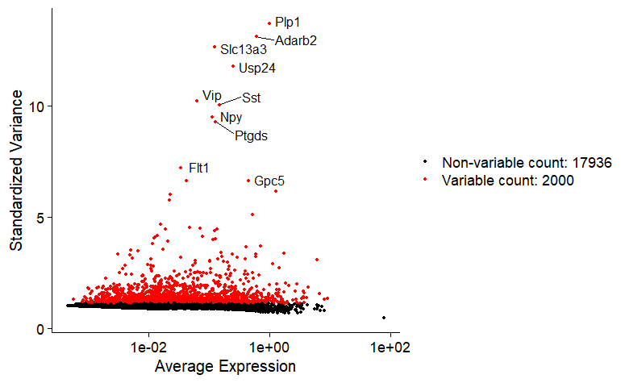

```r
# Plot variable features
plot1 <- VariableFeaturePlot(so)
plot2 <- LabelPoints(plot = plot1, points = top10_var, repel = TRUE)
plot2
```

## 6.9. Scale Data

Scaling standardizes gene expression values by centering (subtracting the mean) and scaling (dividing by standard deviation). This ensures that highly expressed genes do not dominate downstream analyses.

```r
# Scale all genes
all_genes <- rownames(so)
so <- ScaleData(so, features = all_genes)
cat("Scaling complete.\n")
```

```
Scaling complete.
```

```r
cat("Scaled data dimensions:", dim(so[["RNA"]]$scale.data), "\n")
```

```
Scaled data dimensions: 19936 34291
```

## 6.10. Linear Dimensionality Reduction (PCA)

Principal Component Analysis (PCA) reduces the dimensionality of the data while preserving the most important sources of variation.

```r
# Run PCA on variable features
so <- RunPCA(so, features = VariableFeatures(object = so))

# View PCA results
print(so[["pca"]], dims = 1:5, nfeatures = 5)
```

```
PC_ 1
Positive:  Plp1, Mal, Mag, Mog, Cldn11
Negative:  Kcnd2, Lrfn5, Gm26871, Kcnq5, Sntg1
PC_ 2
Positive:  Kcnip4, Gm28928, Nrg1, Kcnh7, Kcp
Negative:  Neat1, Mag, Mog, Mal, Zbtb20
PC_ 3
Positive:  Mag, Mog, Mal, St18, Aspa
Negative:  Atp1a2, Slc1a3, Mertk, Ptprz1, Slco1c1
PC_ 4
Positive:  Gad2, Gad1, Erbb4, Nxph1, Grip1
Negative:  Rorb, Slc1a2, Gm28928, Car10, Atp1a2
PC_ 5
Positive:  Hs3st4, Foxp2, Zfpm2, Garnl3, Cdh18
Negative:  Lingo2, Fam19a1, Unc5d, Pde7b, Calb1
```

### 6.10.1. Visualize PCA Results

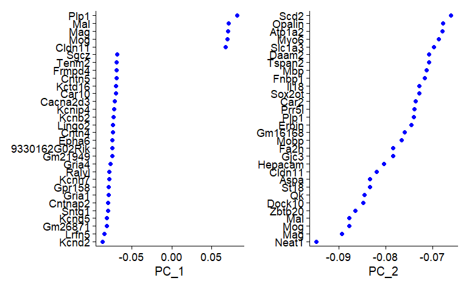

```r
# Visualize top genes contributing to PC1 and PC2
VizDimLoadings(so, dims = 1:2, reduction = "pca")
```

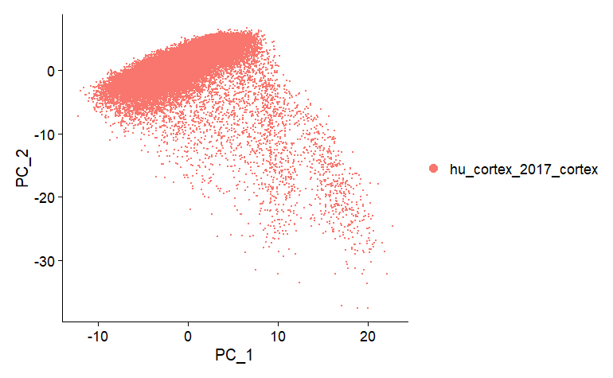

```r
# PCA plot
DimPlot(so, reduction = "pca")
```

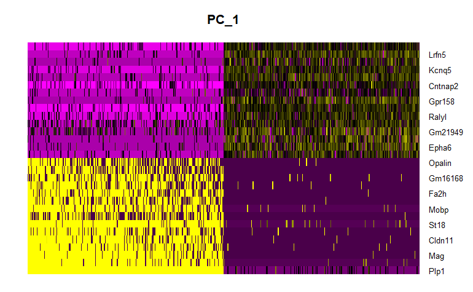

```r
# Heatmap of top genes in first principal component
DimHeatmap(so, dims = 1, cells = 500, balanced = TRUE)
```

### 6.10.2. Determine Dimensionality (Elbow Plot)

The elbow plot helps determine how many principal components capture meaningful biological signal.

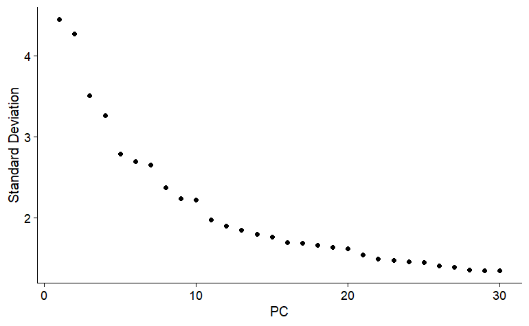

```r
# Elbow plot to determine optimal number of PCs
ElbowPlot(so, ndims = 30)
```

Based on the elbow plot, we select the number of PCs where the curve starts to flatten. Typically 10-20 PCs capture most biological variation.

## 6.11. Clustering

### 6.11.1. Find Neighbors

Construct a shared nearest neighbor (SNN) graph to identify similar cells.

```r
# Find neighbors using selected PCs (adjust dims based on elbow plot)
so <- FindNeighbors(so, dims = 1:15)
```

### 6.11.2. Find Clusters

Cluster cells using the Louvain algorithm at multiple resolutions to explore different granularities.

```r
# Cluster at multiple resolutions
so <- FindClusters(so, resolution = c(0.1, 0.3, 0.5, 0.8, 1.0))
```

```
Modularity Optimizer version 1.3.0 by Ludo Waltman and Nees Jan van Eck

Number of nodes: 34291
Number of edges: 1008757

Running Louvain algorithm...
```

```
Maximum modularity in 10 random starts: 0.9544
Number of communities: 9
Elapsed time: 4 seconds
Modularity Optimizer version 1.3.0 by Ludo Waltman and Nees Jan van Eck

Number of nodes: 34291
Number of edges: 1008757

Running Louvain algorithm...
```

```
Maximum modularity in 10 random starts: 0.9216
Number of communities: 14
Elapsed time: 3 seconds
Modularity Optimizer version 1.3.0 by Ludo Waltman and Nees Jan van Eck

Number of nodes: 34291
Number of edges: 1008757

Running Louvain algorithm...
```

```
Maximum modularity in 10 random starts: 0.8988
Number of communities: 20
Elapsed time: 4 seconds
Modularity Optimizer version 1.3.0 by Ludo Waltman and Nees Jan van Eck

Number of nodes: 34291
Number of edges: 1008757

Running Louvain algorithm...
```

```
Maximum modularity in 10 random starts: 0.8739
Number of communities: 23
Elapsed time: 4 seconds
Modularity Optimizer version 1.3.0 by Ludo Waltman and Nees Jan van Eck

Number of nodes: 34291
Number of edges: 1008757

Running Louvain algorithm...
```

```
Maximum modularity in 10 random starts: 0.8599
Number of communities: 25
Elapsed time: 4 seconds
```

```r
# View clustering results in metadata
head(so@meta.data)
```

|  | orig.ident | nCount_RNA | nFeature_RNA | treatment | animal | percent.mt | RNA_snn_res.0.1 | RNA_snn_res.0.3 | RNA_snn_res.0.5 | RNA_snn_res.0.8 | RNA_snn_res.1 | seurat_clusters |
| --- | --- | --- | --- | --- | --- | --- | --- | --- | --- | --- | --- | --- |
| TTACTTCATCCG | hu_cortex_2017_cortex | 6081 | 2165 | NA | 1 | 0 | 4 | 7 | 12 | 15 | 16 | 16 |
| GTCGTTTTCAGC | hu_cortex_2017_cortex | 6289 | 2435 | NA | 1 | 0 | 0 | 1 | 2 | 12 | 4 | 4 |
| GTTTGCTCCATN | hu_cortex_2017_cortex | 5010 | 2282 | NA | 1 | 0 | 0 | 2 | 5 | 7 | 6 | 6 |
| TCTGCCGGTGGG | hu_cortex_2017_cortex | 4790 | 2192 | NA | 1 | 0 | 5 | 6 | 7 | 9 | 11 | 11 |
| TTAAAAACCATA | hu_cortex_2017_cortex | 5674 | 2256 | NA | 1 | 0 | 2 | 3 | 3 | 3 | 2 | 2 |
| CTCAGCGCTGAN | hu_cortex_2017_cortex | 4963 | 2078 | NA | 1 | 0 | 3 | 9 | 11 | 14 | 15 | 15 |

```r
# Compare different resolutions
cat("Number of clusters at each resolution:\n")
```

```
Number of clusters at each resolution:
```

```r
cat("Resolution 0.1:", length(unique(so$RNA_snn_res.0.1)), "clusters\n")
```

```
Resolution 0.1: 9 clusters
```

```r
cat("Resolution 0.3:", length(unique(so$RNA_snn_res.0.3)), "clusters\n")
```

```
Resolution 0.3: 14 clusters
```

```r
cat("Resolution 0.5:", length(unique(so$RNA_snn_res.0.5)), "clusters\n")
```

```
Resolution 0.5: 20 clusters
```

```r
cat("Resolution 0.8:", length(unique(so$RNA_snn_res.0.8)), "clusters\n")
```

```
Resolution 0.8: 23 clusters
```

```r
cat("Resolution 1.0:", length(unique(so$RNA_snn_res.1)), "clusters\n")
```

```
Resolution 1.0: 25 clusters
```

### 6.11.3. Set Cluster Identity

Choose an appropriate resolution for downstream analysis.

```r
# Set identity to resolution 0.5 (adjust based on your data)
Idents(so) <- "RNA_snn_res.0.5"

cat("Active identity set to resolution 0.5\n")
```

```
Active identity set to resolution 0.5
```

```r
cat("Number of clusters:", length(unique(Idents(so))), "\n")
```

```
Number of clusters: 20
```

## 6.12. Non-linear Dimensionality Reduction (UMAP)

UMAP provides a 2D visualization that preserves local and global structure of the data.

```r
# Run UMAP
so <- RunUMAP(so, dims = 1:15)
```

```
Using method 'umap'
```

### 6.12.1. Visualize UMAP

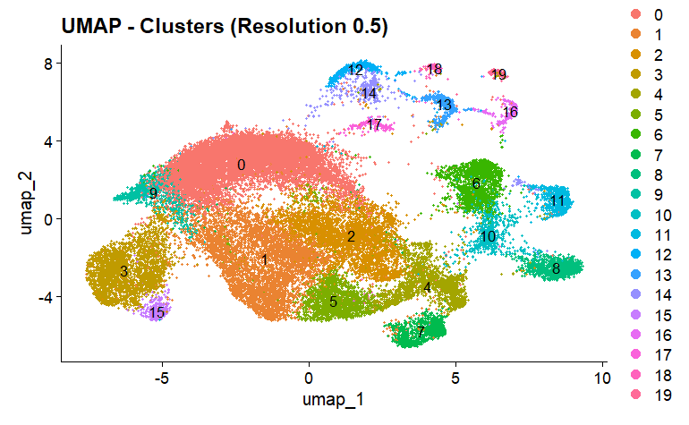

```r
# UMAP plot colored by cluster
DimPlot(so, reduction = "umap", label = TRUE, pt.size = 0.5) +
  ggtitle("UMAP - Clusters (Resolution 0.5)")
```

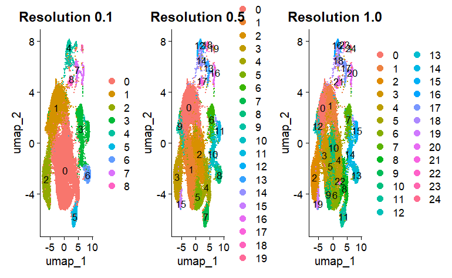

```r
# Compare clustering at different resolutions
p1 <- DimPlot(so, reduction = "umap", group.by = "RNA_snn_res.0.1", label = TRUE) +
  ggtitle("Resolution 0.1")
p2 <- DimPlot(so, reduction = "umap", group.by = "RNA_snn_res.0.5", label = TRUE) +
  ggtitle("Resolution 0.5")
p3 <- DimPlot(so, reduction = "umap", group.by = "RNA_snn_res.1", label = TRUE) +
  ggtitle("Resolution 1.0")

p1 + p2 + p3
```

## 6.13. Cell Type Annotation

### 6.13.1. Find Cluster Markers

Identify marker genes that define each cluster. These genes are differentially expressed in one cluster compared to all others.

```r
# Find markers for all clusters
all_markers <- FindAllMarkers(so,
                               only.pos = TRUE,
                               min.pct = 0.25,
                               logfc.threshold = 0.25)
```

[output not shown]

[output cut: 1764 more lines]

[output not shown]

```r
# View top markers per cluster
top_markers <- all_markers %>%
  group_by(cluster) %>%
  slice_max(n = 5, order_by = avg_log2FC)

print(top_markers)
```

| p_val | avg_log2FC | pct.1 | pct.2 | p_val_adj | cluster | gene |
| --- | --- | --- | --- | --- | --- | --- |
| 1.102783e-219 | 1.1464301 | 0.598 | 0.585 | 2.198509e-215 | 0 | Gm28928 |
| 3.077358e-04 | 0.8226645 | 0.441 | 0.668 | 1.000000e+00 | 0 | Gm42418 |
| 1.986441e-87 | 0.8169509 | 0.627 | 0.740 | 3.960169e-83 | 0 | Nrg1 |
| 1.420215e-13 | 0.7638084 | 0.390 | 0.617 | 2.831340e-09 | 0 | Asic2 |
| 3.126016e-45 | 0.7198227 | 0.362 | 0.630 | 6.232025e-41 | 0 | Dpp10 |
| 0.000000e+00 | 1.9834940 | 0.306 | 0.058 | 0.000000e+00 | 1 | A830036E02Rik |
| 0.000000e+00 | 1.6156299 | 0.255 | 0.076 | 0.000000e+00 | 1 | Nectin3 |
| 0.000000e+00 | 1.2858918 | 0.544 | 0.206 | 0.000000e+00 | 1 | mt-Rnr1 |
| 5.621419e-275 | 1.1571779 | 0.303 | 0.123 | 1.120686e-270 | 1 | Arhgap15 |
| 5.007509e-273 | 1.1010701 | 0.323 | 0.136 | 9.982970e-269 | 1 | Nvl |

[output cut: 90 more lines]

### 6.13.2. Visualize Top Markers

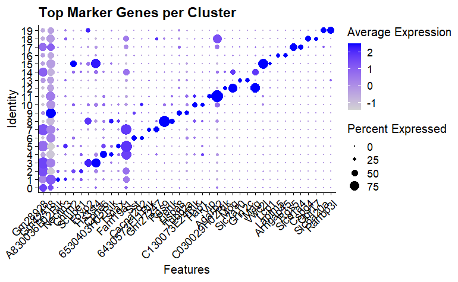

```r
# Get top 2 markers per cluster for visualization
top2_markers <- all_markers %>%
  group_by(cluster) %>%
  slice_max(n = 2, order_by = avg_log2FC) %>%
  pull(gene) %>%
  unique()

# Dot plot of top markers
DotPlot(so, features = top2_markers) +
  RotatedAxis() +
  ggtitle("Top Marker Genes per Cluster")
```

### 6.13.3. Annotate Clusters

Based on marker gene expression, assign cell type labels to clusters.

```r
# Create a named vector mapping cluster numbers to cell types
# IMPORTANT: Adjust these based on YOUR marker expression patterns!
# This is an example - you need to examine your plots and assign accordingly

# First, check current cluster IDs
cat("Current cluster IDs:\n")
```

```
Current cluster IDs:
```

```r
print(levels(Idents(so)))
```

```
 [1] "0"  "1"  "2"  "3"  "4"  "5"  "6"  "7"  "8"  "9"  "10" "11" "12" "13" "14" "15" "16" "17" "18" "19"
```

```r
# Example annotation (MODIFY based on your actual marker expression!)
# You need to look at DotPlot and FeaturePlot results to determine which cluster is which cell type
cluster_annotations <- c(
  "0" = "Excitatory Neurons",
  "1" = "Inhibitory Neurons",
  "2" = "Oligodendrocytes",
  "3" = "Astrocytes",
  "4" = "Microglia",
  "5" = "OPCs",
  "6" = "Endothelial"
  # Add more clusters as needed based on your data
)

# Only annotate clusters that exist in your data
existing_clusters <- as.character(unique(Idents(so)))
cluster_annotations <- cluster_annotations[names(cluster_annotations) %in% existing_clusters]

# Add cell type annotations to metadata
so$cell_type <- as.character(Idents(so))
for(cluster_id in names(cluster_annotations)) {
  so$cell_type[so$cell_type == cluster_id] <- cluster_annotations[cluster_id]
}

# View annotation summary
cat("\nCell type annotations:\n")
```

```
Cell type annotations:
```

```r
print(table(so$cell_type))
```

```
                10                 11                 12                 13                 14                 15                 16                 17
               730                704                554                532                393                321                269                214
                18                 19                  7                  8                  9         Astrocytes        Endothelial Excitatory Neurons
               149                144               1004                895                874               2771               1650               9728
Inhibitory Neurons          Microglia   Oligodendrocytes               OPCs
              5848               1913               3834               1764
```

### 6.13.4. Visualize Annotated Cell Types

[figure not shown]

```r
# UMAP with cell type annotations
DimPlot(so, reduction = "umap", group.by = "cell_type", label = TRUE, pt.size = 0.5) +
  ggtitle("UMAP - Annotated Cell Types (Human Cortex)")
```

## 6.14. Cell-Type Specific Differential Expression (Optional)

This section identifies genes that are differentially expressed between specific cell types, which can be compared with bulk RNA-seq results.

### 6.14.1. Compare Two Cell Types

```r
# Example: Compare excitatory vs inhibitory neurons
# Adjust cell type names based on your annotations

Idents(so) <- "cell_type"

# Check available cell types
cat("Available cell types for comparison:\n")
```

```
Available cell types for comparison:
```

```r
print(unique(Idents(so)))
```

```
 [1] 12                 Oligodendrocytes   OPCs               7                  Astrocytes         11                 13                 Inhibitory Neurons
 [9] 19                 Endothelial        18                 Excitatory Neurons 9                  Microglia          16                 14
[17] 17                 15                 10                 8
Levels: 12 Oligodendrocytes OPCs 7 Astrocytes 11 13 Inhibitory Neurons 19 Endothelial 18 Excitatory Neurons 9 Microglia 16 14 17 15 10 8
```

```r
# Find markers between two cell types (example)
# Uncomment and modify based on your cell types

# de_neurons <- FindMarkers(so,
#                           ident.1 = "Excitatory Neurons",
#                           ident.2 = "Inhibitory Neurons",
#                           min.pct = 0.25)
#
# head(de_neurons, 20)
```

### 6.14.2. Cell Type Proportions

[figure not shown]

```r
# Calculate cell type proportions
cell_type_counts <- table(so$cell_type)
cell_type_props <- prop.table(cell_type_counts) * 100

# Create proportion dataframe
prop_df <- data.frame(
  CellType = names(cell_type_props),
  Proportion = as.numeric(cell_type_props)
)

# Plot cell type proportions
ggplot(prop_df, aes(x = reorder(CellType, -Proportion), y = Proportion, fill = CellType)) +
  geom_bar(stat = "identity") +
  theme_minimal() +
  theme(axis.text.x = element_text(angle = 45, hjust = 1),
        legend.position = "none") +
  labs(title = "Cell Type Proportions in Human Cortex",
       x = "Cell Type",
       y = "Percentage of Cells")
```